# Codebook

Here, we’re just setting a few options.

```r
knitr::opts_chunk$set(
  warning = TRUE, # show warnings during codebook generation
  message = TRUE, # show messages during codebook generation
  error = TRUE, # do not interrupt codebook generation in case of errors,
                # usually better for debugging
  echo = TRUE  # show R code
)
ggplot2::theme_set(ggplot2::theme_bw())
```

Now, we’re preparing our data for the codebook.

```r
library(codebook)
#codebook_data <- rio::import
# to import an SPSS file from the same folder uncomment and edit the line below
 codebook_data <- rio::import("tidyData.txt")
# for Stata
# codebook_data <- rio::import("mydata.dta")
# for CSV
# codebook_data <- rio::import("mydata.csv")

# omit the following lines, if your missing values are already properly labelled
codebook_data <- detect_missing(codebook_data,
    only_labelled = TRUE, # only labelled values are autodetected as
                                   # missing
    negative_values_are_missing = FALSE, # negative values are missing values
    ninety_nine_problems = TRUE,   # 99/999 are missing values, if they
                                   # are more than 5 MAD from the median
    )

# If you are not using formr, the codebook package needs to guess which items
# form a scale. The following line finds item aggregates with names like this:
# scale = scale_1 + scale_2R + scale_3R
# identifying these aggregates allows the codebook function to
# automatically compute reliabilities.
# However, it will not reverse items automatically.
codebook_data <- detect_scales(codebook_data)
```

Create codebook

```r
codebook(codebook_data)
```

```
## No missing values.
```

### Metadata

#### Description

**Dataset name**: codebook_data

The dataset has N=180 rows and 69 columns. 180 rows have no missing values on any column.

**Metadata for search engines**

- **Date published**: 2021-09-17

| x |
| --- |
| V1 |
| subject |
| activity |
| tBodyAcc.mean…X |
| tBodyAcc.mean…Y |
| tBodyAcc.mean…Z |
| tBodyAcc.std…X |
| tBodyAcc.std…Y |
| tBodyAcc.std…Z |
| tGravityAcc.mean…X |
| tGravityAcc.mean…Y |
| tGravityAcc.mean…Z |
| tGravityAcc.std…X |
| tGravityAcc.std…Y |
| tGravityAcc.std…Z |
| tBodyAccJerk.mean…X |
| tBodyAccJerk.mean…Y |
| tBodyAccJerk.mean…Z |
| tBodyAccJerk.std…X |
| tBodyAccJerk.std…Y |
| tBodyAccJerk.std…Z |
| tBodyGyro.mean…X |
| tBodyGyro.mean…Y |
| tBodyGyro.mean…Z |
| tBodyGyro.std…X |
| tBodyGyro.std…Y |
| tBodyGyro.std…Z |
| tBodyGyroJerk.mean…X |
| tBodyGyroJerk.mean…Y |
| tBodyGyroJerk.mean…Z |
| tBodyGyroJerk.std…X |
| tBodyGyroJerk.std…Y |
| tBodyGyroJerk.std…Z |
| tBodyAccMag.mean.. |
| tBodyAccMag.std.. |
| tGravityAccMag.mean.. |
| tGravityAccMag.std.. |
| tBodyAccJerkMag.mean.. |
| tBodyAccJerkMag.std.. |
| tBodyGyroMag.mean.. |
| tBodyGyroMag.std.. |
| tBodyGyroJerkMag.mean.. |
| tBodyGyroJerkMag.std.. |
| fBodyAcc.mean…X |
| fBodyAcc.mean…Y |
| fBodyAcc.mean…Z |
| fBodyAcc.std…X |
| fBodyAcc.std…Y |
| fBodyAcc.std…Z |
| fBodyAccJerk.mean…X |
| fBodyAccJerk.mean…Y |
| fBodyAccJerk.mean…Z |
| fBodyAccJerk.std…X |
| fBodyAccJerk.std…Y |
| fBodyAccJerk.std…Z |
| fBodyGyro.mean…X |
| fBodyGyro.mean…Y |
| fBodyGyro.mean…Z |
| fBodyGyro.std…X |
| fBodyGyro.std…Y |
| fBodyGyro.std…Z |
| fBodyAccMag.mean.. |
| fBodyAccMag.std.. |
| fBodyBodyAccJerkMag.mean.. |
| fBodyBodyAccJerkMag.std.. |
| fBodyBodyGyroMag.mean.. |
| fBodyBodyGyroMag.std.. |
| fBodyBodyGyroJerkMag.mean.. |
| fBodyBodyGyroJerkMag.std.. |

### V1

#### Distribution

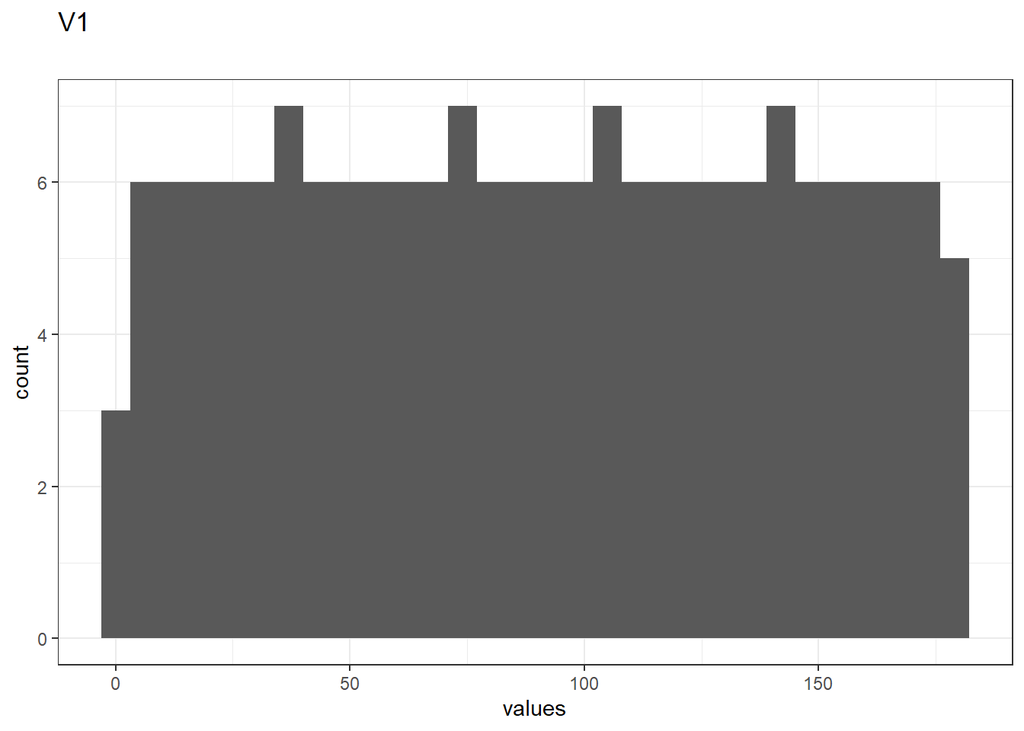

Distribution of values for V1

0 missing values.

#### Summary statistics

| name | data_type | n_missing | complete_rate | min | median | max | mean | sd | hist | label |
| --- | --- | --- | --- | --- | --- | --- | --- | --- | --- | --- |
| V1 | numeric | 0 | 1 | 1 | 90 | 180 | 90.5 | 52.10566 | ▇▇▇▇▇ | NA |

### subject

#### Distribution

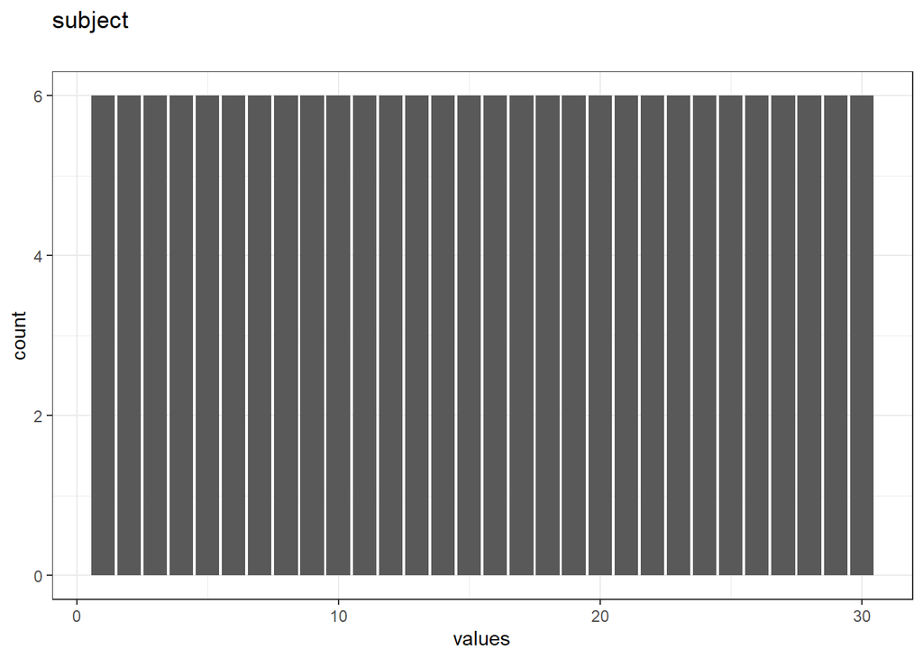

Distribution of values for subject

0 missing values.

#### Summary statistics

| name | data_type | n_missing | complete_rate | min | median | max | mean | sd | hist | label |
| --- | --- | --- | --- | --- | --- | --- | --- | --- | --- | --- |
| subject | numeric | 0 | 1 | 1 | 16 | 30 | 15.5 | 8.679585 | ▇▇▇▇▇ | NA |

### activity

#### Distribution

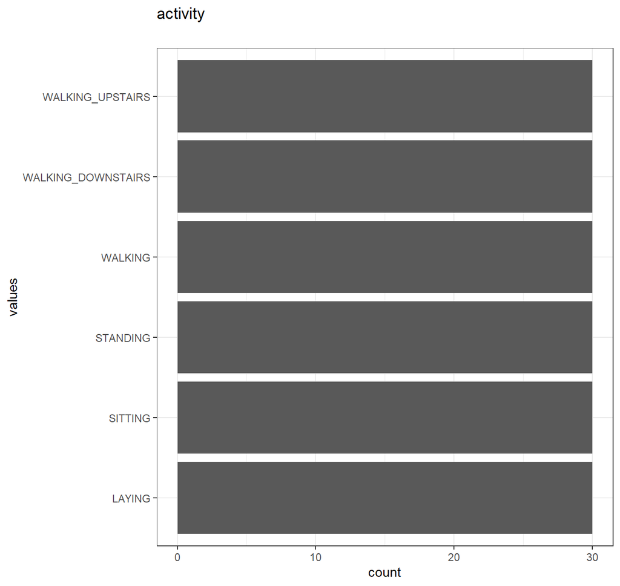

Distribution of values for activity

0 missing values.

#### Summary statistics

| name | data_type | n_missing | complete_rate | n_unique | empty | min | max | whitespace | label |
| --- | --- | --- | --- | --- | --- | --- | --- | --- | --- |
| activity | character | 0 | 1 | 6 | 0 | 6 | 18 | 0 | NA |

### tBodyAcc.mean…X

#### Distribution

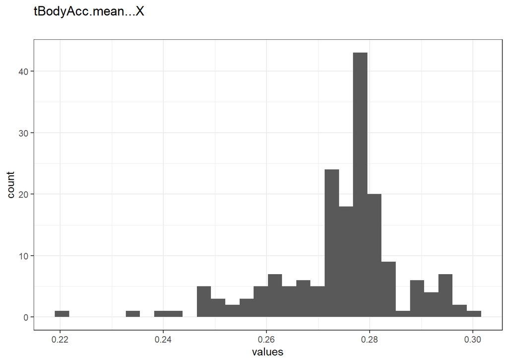

Distribution of values for tBodyAcc.mean…X

0 missing values.

#### Summary statistics

| name | data_type | n_missing | complete_rate | min | median | max | mean | sd | hist | label |
| --- | --- | --- | --- | --- | --- | --- | --- | --- | --- | --- |
| tBodyAcc.mean…X | numeric | 0 | 1 | 0.22 | 0.28 | 0.3 | 0.2743027 | 0.0121646 | ▁▁▂▇▂ | NA |

### tBodyAcc.mean…Y

#### Distribution

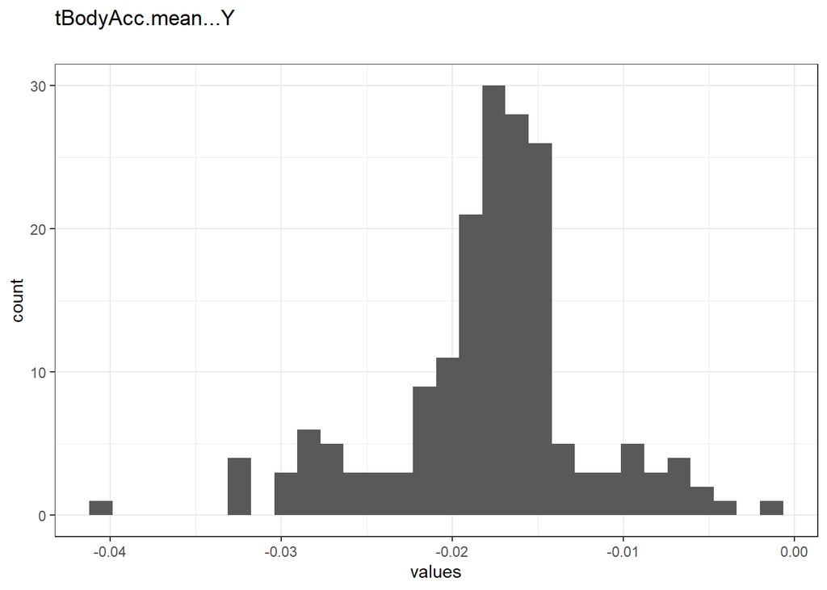

Distribution of values for tBodyAcc.mean…Y

0 missing values.

#### Summary statistics

| name | data_type | n_missing | complete_rate | min | median | max | mean | sd | hist | label |
| --- | --- | --- | --- | --- | --- | --- | --- | --- | --- | --- |
| tBodyAcc.mean…Y | numeric | 0 | 1 | -0.041 | -0.017 | -0.0013 | -0.0178755 | 0.0057712 | ▁▂▇▇▁ | NA |

### tBodyAcc.mean…Z

#### Distribution

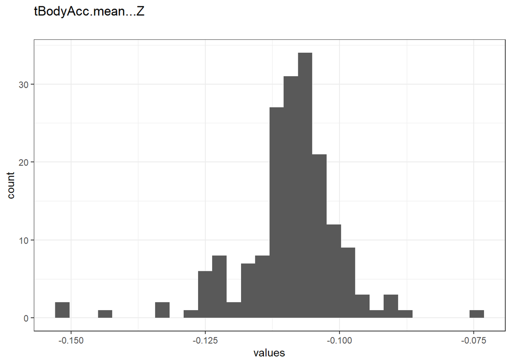

Distribution of values for tBodyAcc.mean…Z

0 missing values.

#### Summary statistics

| name | data_type | n_missing | complete_rate | min | median | max | mean | sd | hist | label |
| --- | --- | --- | --- | --- | --- | --- | --- | --- | --- | --- |
| tBodyAcc.mean…Z | numeric | 0 | 1 | -0.15 | -0.11 | -0.075 | -0.1091638 | 0.009582 | ▁▁▇▅▁ | NA |

### tBodyAcc.std…X

#### Distribution

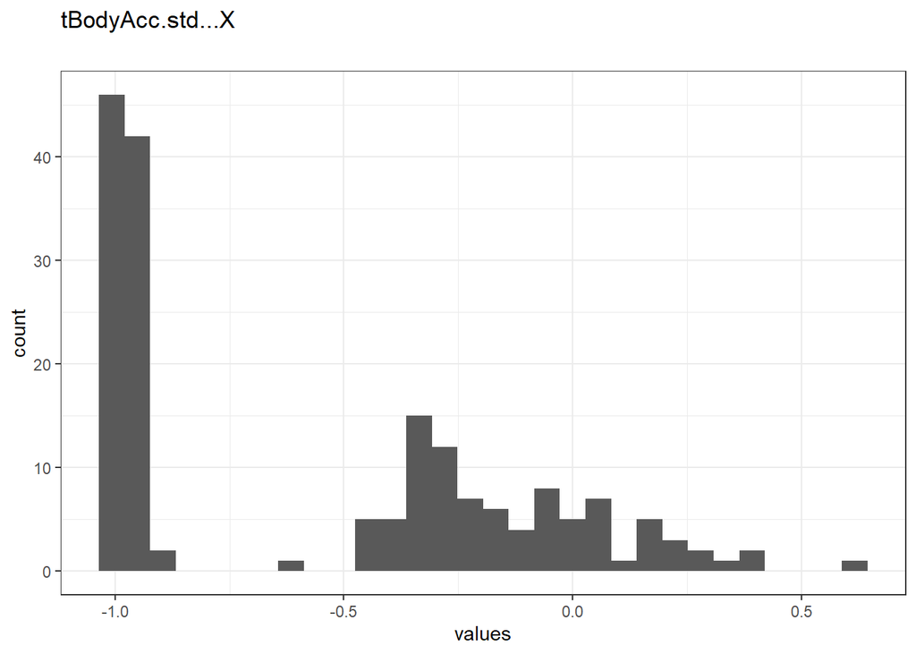

Distribution of values for tBodyAcc.std…X

0 missing values.

#### Summary statistics

| name | data_type | n_missing | complete_rate | min | median | max | mean | sd | hist | label |
| --- | --- | --- | --- | --- | --- | --- | --- | --- | --- | --- |
| tBodyAcc.std…X | numeric | 0 | 1 | -1 | -0.75 | 0.63 | -0.5576901 | 0.4516911 | ▇▂▅▂▁ | NA |

### tBodyAcc.std…Y

#### Distribution

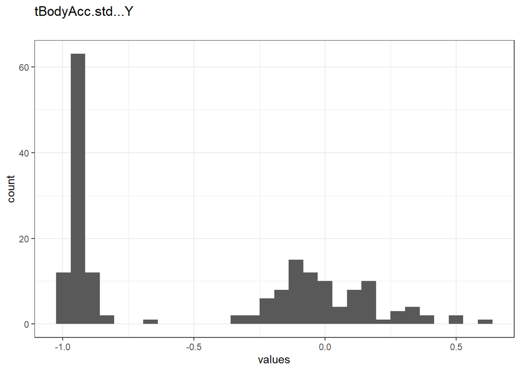

Distribution of values for tBodyAcc.std…Y

0 missing values.

#### Summary statistics

| name | data_type | n_missing | complete_rate | min | median | max | mean | sd | hist | label |
| --- | --- | --- | --- | --- | --- | --- | --- | --- | --- | --- |
| tBodyAcc.std…Y | numeric | 0 | 1 | -0.99 | -0.51 | 0.62 | -0.4604626 | 0.496565 | ▇▁▅▃▁ | NA |

### tBodyAcc.std…Z

#### Distribution

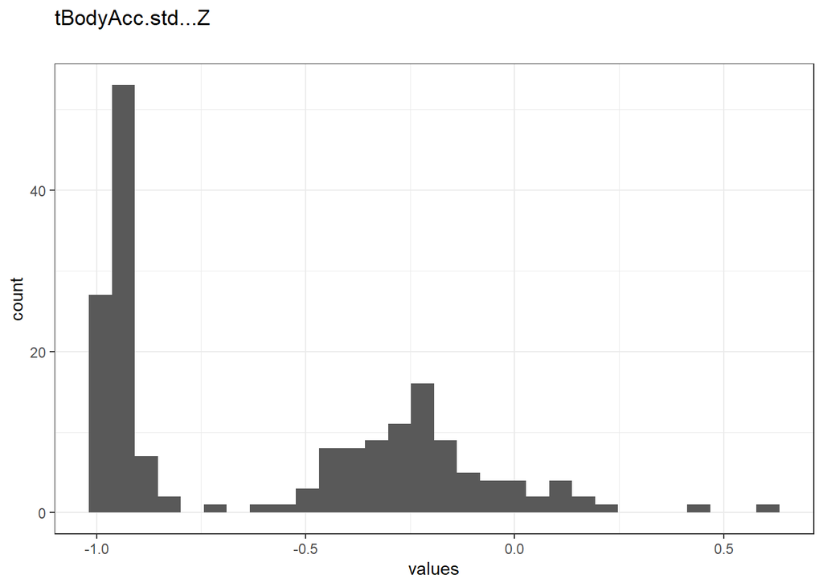

Distribution of values for tBodyAcc.std…Z

0 missing values.

#### Summary statistics

| name | data_type | n_missing | complete_rate | min | median | max | mean | sd | hist | label |
| --- | --- | --- | --- | --- | --- | --- | --- | --- | --- | --- |
| tBodyAcc.std…Z | numeric | 0 | 1 | -0.99 | -0.65 | 0.61 | -0.5755602 | 0.3955439 | ▇▂▅▁▁ | NA |

### tGravityAcc.mean…X

#### Distribution

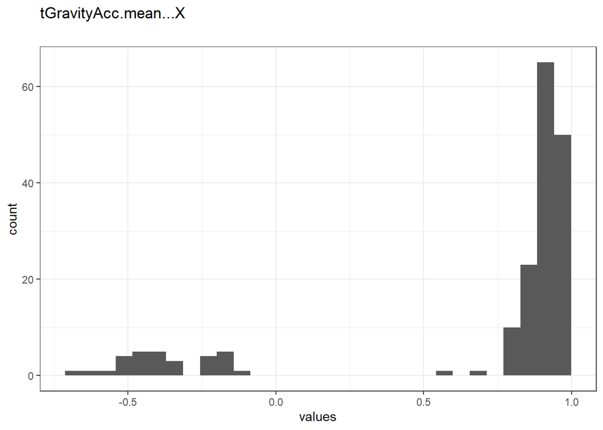

Distribution of values for tGravityAcc.mean…X

0 missing values.

#### Summary statistics

| name | data_type | n_missing | complete_rate | min | median | max | mean | sd | hist | label |
| --- | --- | --- | --- | --- | --- | --- | --- | --- | --- | --- |
| tGravityAcc.mean…X | numeric | 0 | 1 | -0.68 | 0.92 | 0.97 | 0.6974775 | 0.4872534 | ▁▁▁▁▇ | NA |

### tGravityAcc.mean…Y

#### Distribution

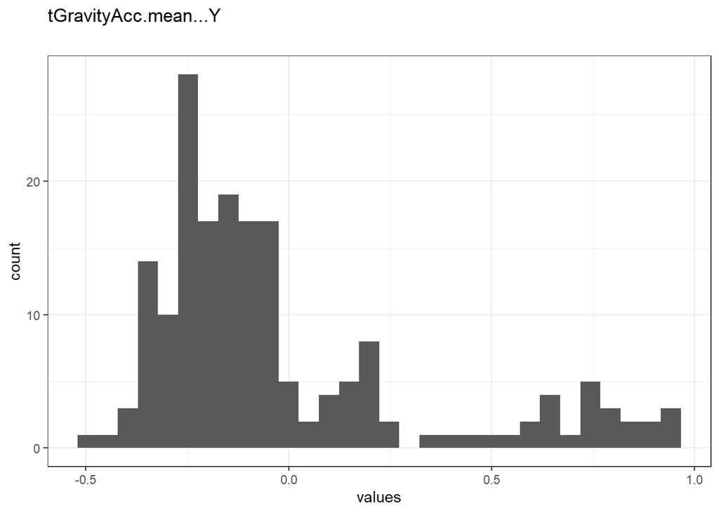

Distribution of values for tGravityAcc.mean…Y

0 missing values.

#### Summary statistics

| name | data_type | n_missing | complete_rate | min | median | max | mean | sd | hist | label |
| --- | --- | --- | --- | --- | --- | --- | --- | --- | --- | --- |
| tGravityAcc.mean…Y | numeric | 0 | 1 | -0.48 | -0.13 | 0.96 | -0.0162128 | 0.3452376 | ▇▇▂▁▂ | NA |

### tGravityAcc.mean…Z

#### Distribution

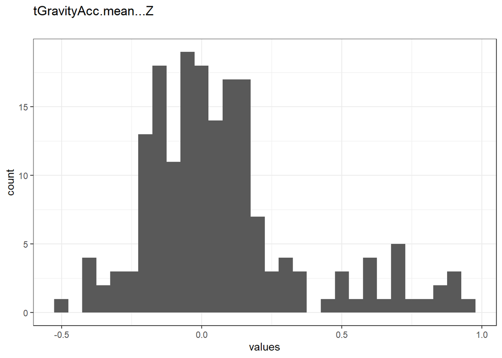

Distribution of values for tGravityAcc.mean…Z

0 missing values.

#### Summary statistics

| name | data_type | n_missing | complete_rate | min | median | max | mean | sd | hist | label |
| --- | --- | --- | --- | --- | --- | --- | --- | --- | --- | --- |
| tGravityAcc.mean…Z | numeric | 0 | 1 | -0.5 | 0.024 | 0.96 | 0.0741279 | 0.2887919 | ▂▇▃▁▁ | NA |

### tGravityAcc.std…X

#### Distribution

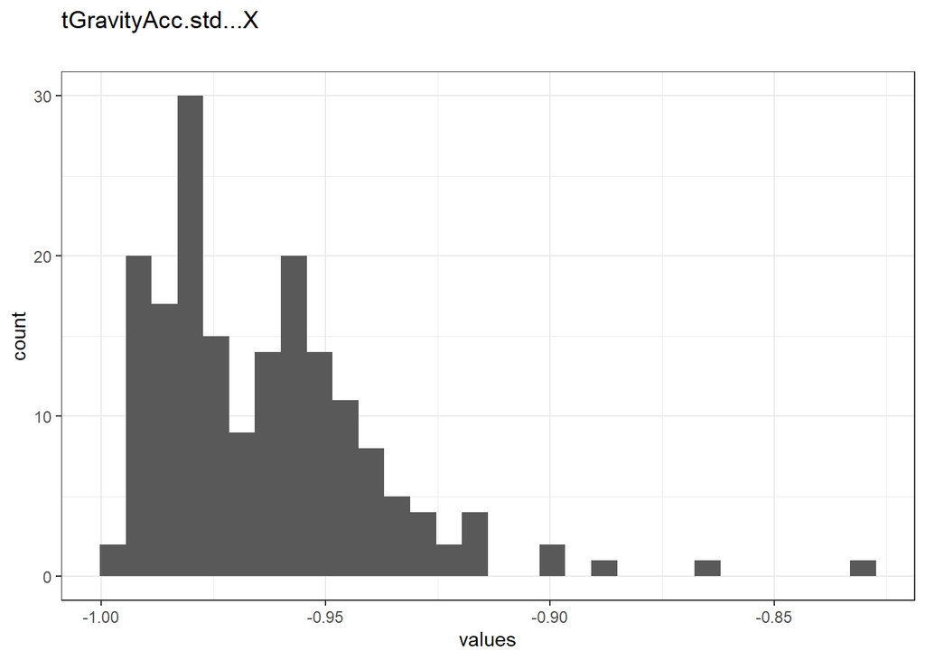

Distribution of values for tGravityAcc.std…X

0 missing values.

#### Summary statistics

| name | data_type | n_missing | complete_rate | min | median | max | mean | sd | hist | label |
| --- | --- | --- | --- | --- | --- | --- | --- | --- | --- | --- |
| tGravityAcc.std…X | numeric | 0 | 1 | -1 | -0.97 | -0.83 | -0.9637525 | 0.0250344 | ▇▆▁▁▁ | NA |

### tGravityAcc.std…Y

#### Distribution

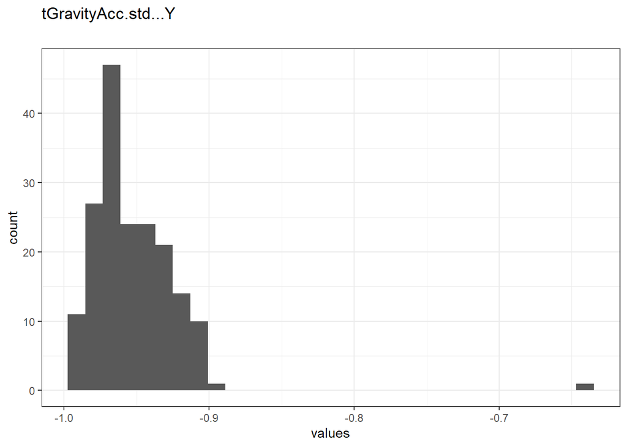

Distribution of values for tGravityAcc.std…Y

0 missing values.

#### Summary statistics

| name | data_type | n_missing | complete_rate | min | median | max | mean | sd | hist | label |
| --- | --- | --- | --- | --- | --- | --- | --- | --- | --- | --- |
| tGravityAcc.std…Y | numeric | 0 | 1 | -0.99 | -0.96 | -0.64 | -0.9524296 | 0.0326557 | ▇▁▁▁▁ | NA |

### tGravityAcc.std…Z

#### Distribution

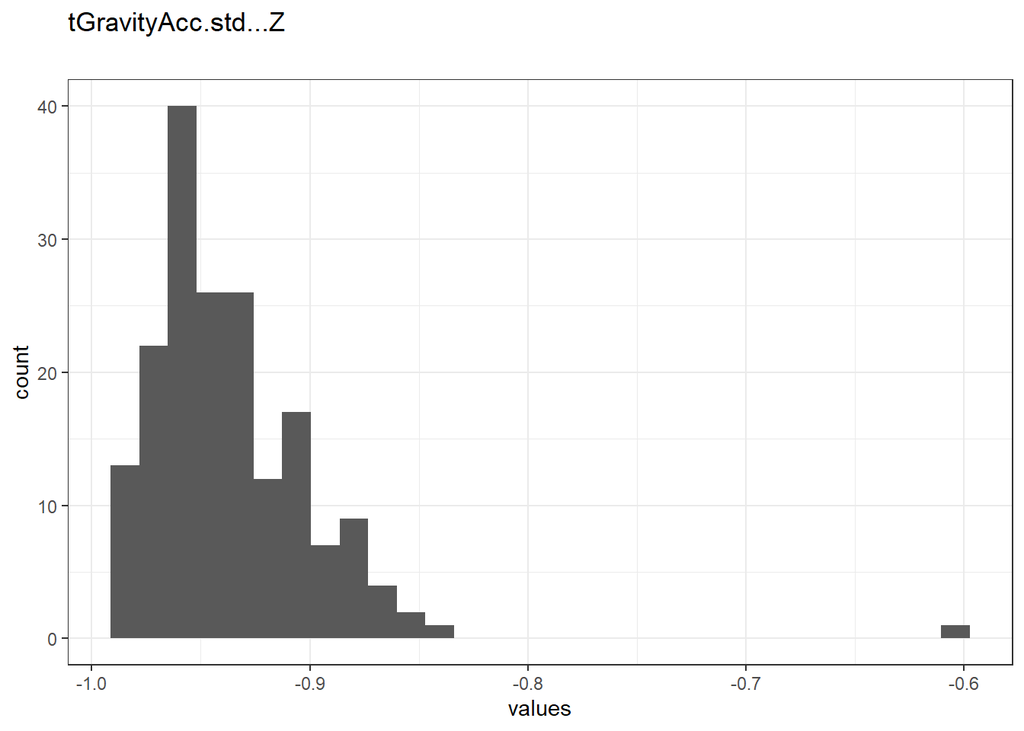

Distribution of values for tGravityAcc.std…Z

0 missing values.

#### Summary statistics

| name | data_type | n_missing | complete_rate | min | median | max | mean | sd | hist | label |
| --- | --- | --- | --- | --- | --- | --- | --- | --- | --- | --- |
| tGravityAcc.std…Z | numeric | 0 | 1 | -0.99 | -0.95 | -0.61 | -0.936401 | 0.0402912 | ▇▂▁▁▁ | NA |

### tBodyAccJerk.mean…X

#### Distribution

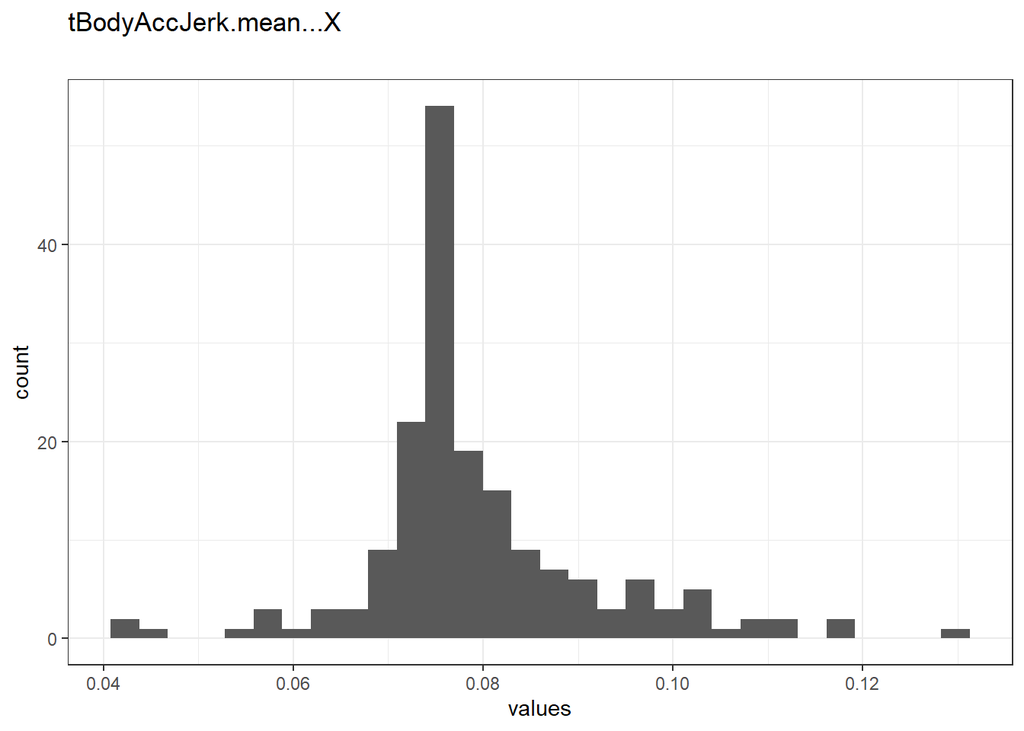

Distribution of values for tBodyAccJerk.mean…X

0 missing values.

#### Summary statistics

| name | data_type | n_missing | complete_rate | min | median | max | mean | sd | hist | label |
| --- | --- | --- | --- | --- | --- | --- | --- | --- | --- | --- |
| tBodyAccJerk.mean…X | numeric | 0 | 1 | 0.043 | 0.076 | 0.13 | 0.0794736 | 0.012588 | ▁▇▃▂▁ | NA |

### tBodyAccJerk.mean…Y

#### Distribution

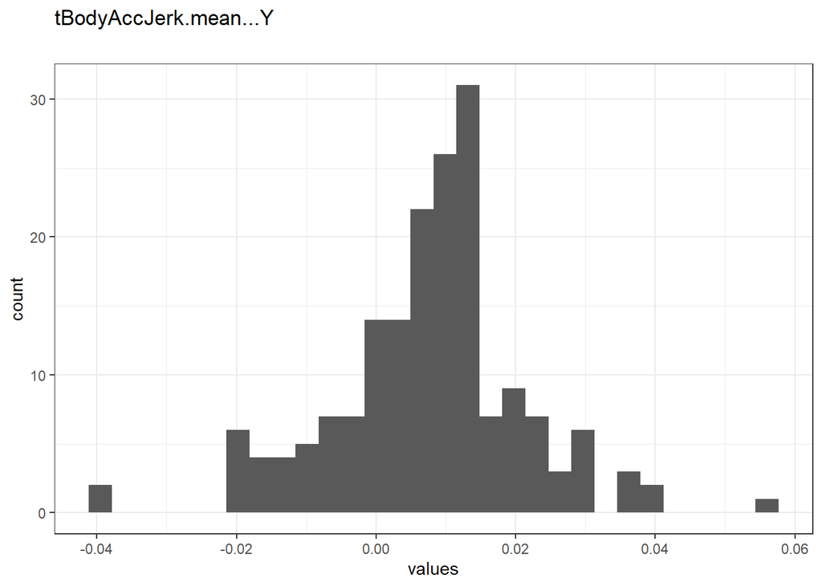

Distribution of values for tBodyAccJerk.mean…Y

0 missing values.

#### Summary statistics

| name | data_type | n_missing | complete_rate | min | median | max | mean | sd | hist | label |
| --- | --- | --- | --- | --- | --- | --- | --- | --- | --- | --- |
| tBodyAccJerk.mean…Y | numeric | 0 | 1 | -0.039 | 0.0095 | 0.057 | 0.0075652 | 0.0135764 | ▁▃▇▂▁ | NA |

### tBodyAccJerk.mean…Z

#### Distribution

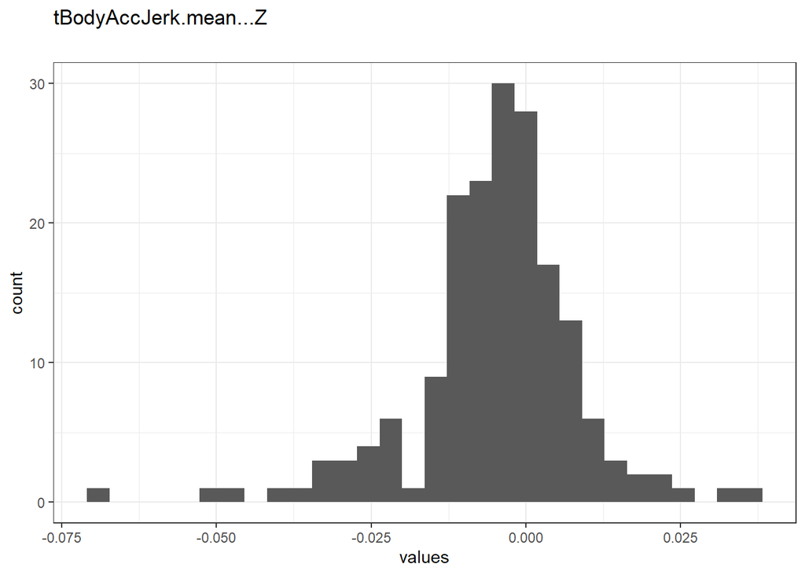

Distribution of values for tBodyAccJerk.mean…Z

0 missing values.

#### Summary statistics

| name | data_type | n_missing | complete_rate | min | median | max | mean | sd | hist | label |
| --- | --- | --- | --- | --- | --- | --- | --- | --- | --- | --- |
| tBodyAccJerk.mean…Z | numeric | 0 | 1 | -0.067 | -0.0039 | 0.038 | -0.0049534 | 0.0134621 | ▁▁▇▇▁ | NA |

### tBodyAccJerk.std…X

#### Distribution

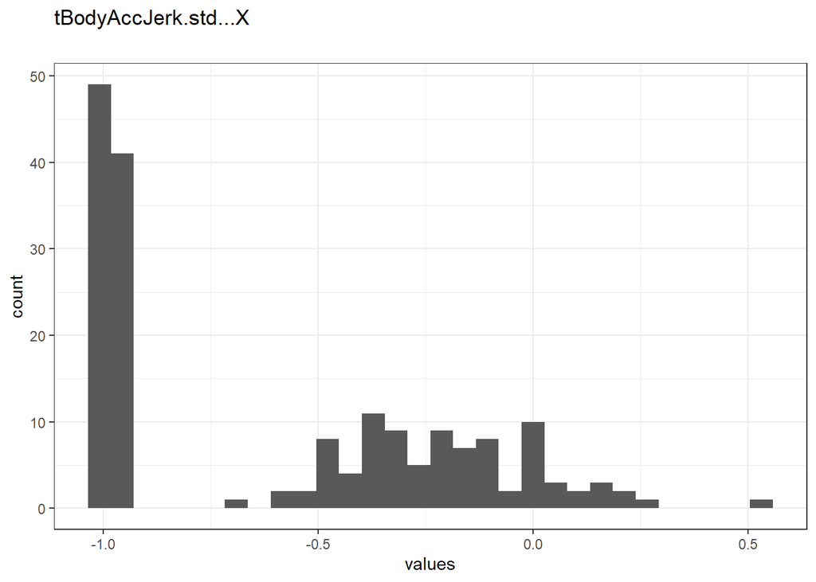

Distribution of values for tBodyAccJerk.std…X

0 missing values.

#### Summary statistics

| name | data_type | n_missing | complete_rate | min | median | max | mean | sd | hist | label |
| --- | --- | --- | --- | --- | --- | --- | --- | --- | --- | --- |
| tBodyAccJerk.std…X | numeric | 0 | 1 | -0.99 | -0.81 | 0.54 | -0.5949467 | 0.4175865 | ▇▂▅▂▁ | NA |

### tBodyAccJerk.std…Y

#### Distribution

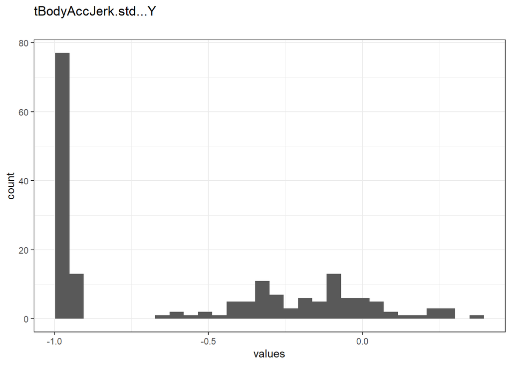

Distribution of values for tBodyAccJerk.std…Y

0 missing values.

#### Summary statistics

| name | data_type | n_missing | complete_rate | min | median | max | mean | sd | hist | label |
| --- | --- | --- | --- | --- | --- | --- | --- | --- | --- | --- |
| tBodyAccJerk.std…Y | numeric | 0 | 1 | -0.99 | -0.78 | 0.36 | -0.5654147 | 0.4330871 | ▇▁▃▃▁ | NA |

### tBodyAccJerk.std…Z

#### Distribution

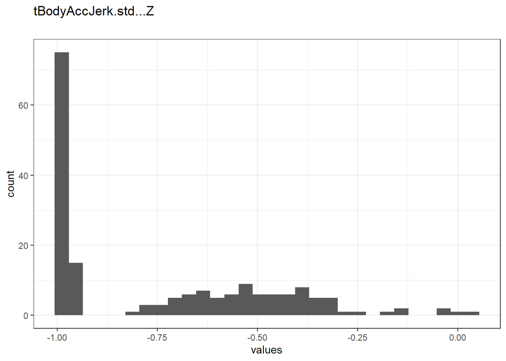

Distribution of values for tBodyAccJerk.std…Z

0 missing values.

#### Summary statistics

| name | data_type | n_missing | complete_rate | min | median | max | mean | sd | hist | label |
| --- | --- | --- | --- | --- | --- | --- | --- | --- | --- | --- |
| tBodyAccJerk.std…Z | numeric | 0 | 1 | -0.99 | -0.88 | 0.031 | -0.7359577 | 0.2768479 | ▇▂▃▁▁ | NA |

### tBodyGyro.mean…X

#### Distribution

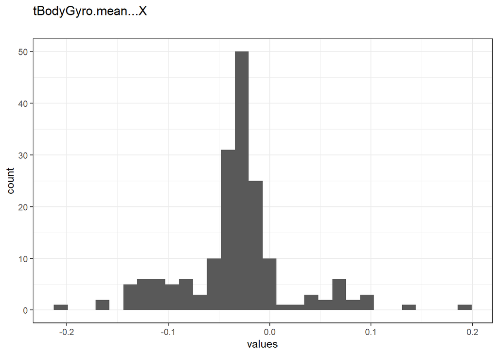

Distribution of values for tBodyGyro.mean…X

0 missing values.

#### Summary statistics

| name | data_type | n_missing | complete_rate | min | median | max | mean | sd | hist | label |
| --- | --- | --- | --- | --- | --- | --- | --- | --- | --- | --- |
| tBodyGyro.mean…X | numeric | 0 | 1 | -0.21 | -0.029 | 0.19 | -0.0324372 | 0.0540518 | ▁▂▇▁▁ | NA |

### tBodyGyro.mean…Y

#### Distribution

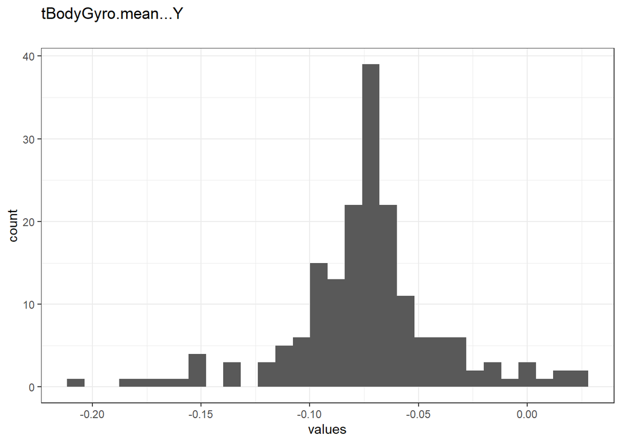

Distribution of values for tBodyGyro.mean…Y

0 missing values.

#### Summary statistics

| name | data_type | n_missing | complete_rate | min | median | max | mean | sd | hist | label |
| --- | --- | --- | --- | --- | --- | --- | --- | --- | --- | --- |
| tBodyGyro.mean…Y | numeric | 0 | 1 | -0.2 | -0.073 | 0.027 | -0.0742596 | 0.0355415 | ▁▁▇▃▁ | NA |

### tBodyGyro.mean…Z

#### Distribution

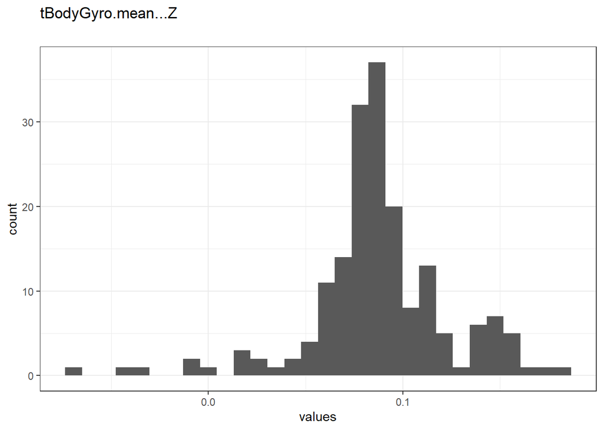

Distribution of values for tBodyGyro.mean…Z

0 missing values.

#### Summary statistics

| name | data_type | n_missing | complete_rate | min | median | max | mean | sd | hist | label |
| --- | --- | --- | --- | --- | --- | --- | --- | --- | --- | --- |
| tBodyGyro.mean…Z | numeric | 0 | 1 | -0.072 | 0.085 | 0.18 | 0.0874446 | 0.0362125 | ▁▁▃▇▂ | NA |

### tBodyGyro.std…X

#### Distribution

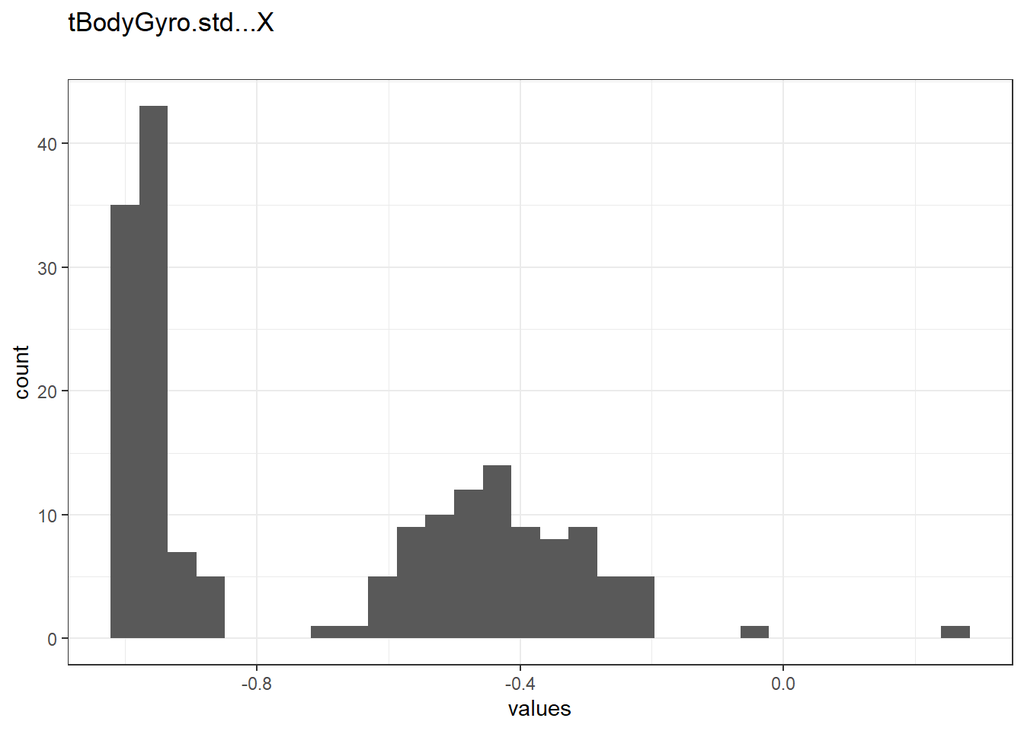

Distribution of values for tBodyGyro.std…X

0 missing values.

#### Summary statistics

| name | data_type | n_missing | complete_rate | min | median | max | mean | sd | hist | label |
| --- | --- | --- | --- | --- | --- | --- | --- | --- | --- | --- |
| tBodyGyro.std…X | numeric | 0 | 1 | -0.99 | -0.79 | 0.27 | -0.6916399 | 0.2910189 | ▇▃▅▁▁ | NA |

### tBodyGyro.std…Y

#### Distribution

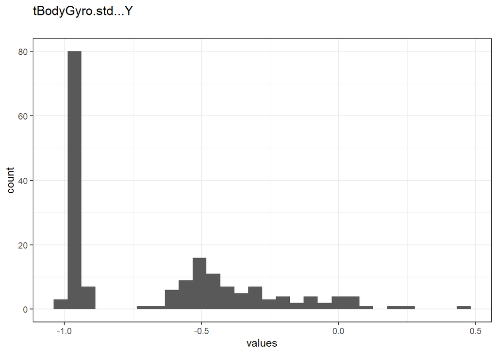

Distribution of values for tBodyGyro.std…Y

0 missing values.

#### Summary statistics

| name | data_type | n_missing | complete_rate | min | median | max | mean | sd | hist | label |
| --- | --- | --- | --- | --- | --- | --- | --- | --- | --- | --- |
| tBodyGyro.std…Y | numeric | 0 | 1 | -0.99 | -0.8 | 0.48 | -0.653302 | 0.3520252 | ▇▅▂▁▁ | NA |

### tBodyGyro.std…Z

#### Distribution

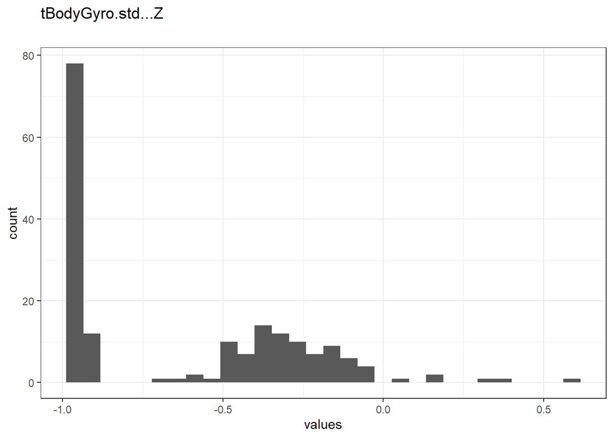

Distribution of values for tBodyGyro.std…Z

0 missing values.

#### Summary statistics

| name | data_type | n_missing | complete_rate | min | median | max | mean | sd | hist | label |
| --- | --- | --- | --- | --- | --- | --- | --- | --- | --- | --- |
| tBodyGyro.std…Z | numeric | 0 | 1 | -0.99 | -0.8 | 0.56 | -0.6164353 | 0.3730264 | ▇▂▅▁▁ | NA |

### tBodyGyroJerk.mean…X

#### Distribution

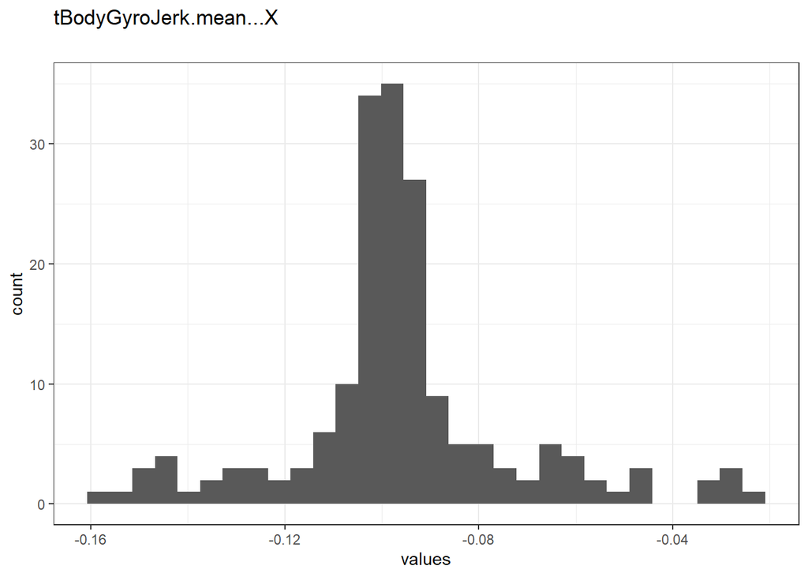

Distribution of values for tBodyGyroJerk.mean…X

0 missing values.

#### Summary statistics

| name | data_type | n_missing | complete_rate | min | median | max | mean | sd | hist | label |
| --- | --- | --- | --- | --- | --- | --- | --- | --- | --- | --- |
| tBodyGyroJerk.mean…X | numeric | 0 | 1 | -0.16 | -0.099 | -0.022 | -0.0960568 | 0.0233458 | ▁▂▇▁▁ | NA |

### tBodyGyroJerk.mean…Y

#### Distribution

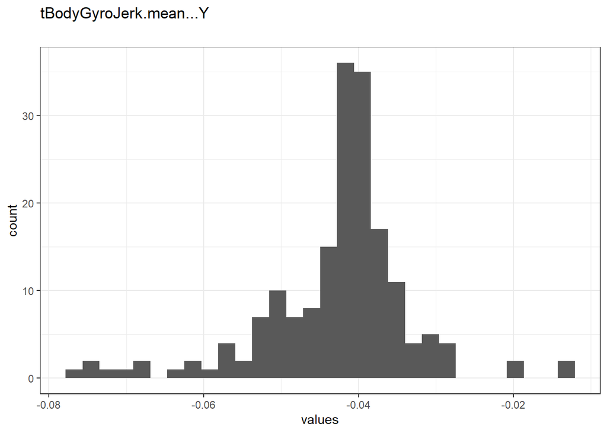

Distribution of values for tBodyGyroJerk.mean…Y

0 missing values.

#### Summary statistics

| name | data_type | n_missing | complete_rate | min | median | max | mean | sd | hist | label |
| --- | --- | --- | --- | --- | --- | --- | --- | --- | --- | --- |
| tBodyGyroJerk.mean…Y | numeric | 0 | 1 | -0.077 | -0.041 | -0.013 | -0.0426928 | 0.009532 | ▁▂▇▃▁ | NA |

### tBodyGyroJerk.mean…Z

#### Distribution

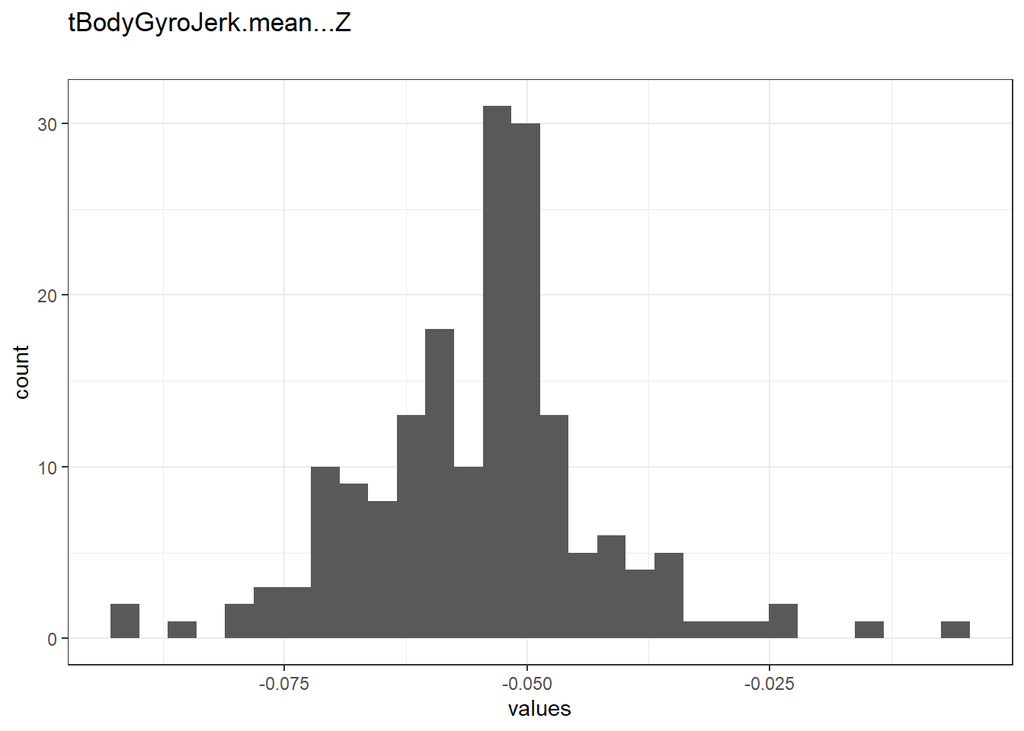

Distribution of values for tBodyGyroJerk.mean…Z

0 missing values.

#### Summary statistics

| name | data_type | n_missing | complete_rate | min | median | max | mean | sd | hist | label |
| --- | --- | --- | --- | --- | --- | --- | --- | --- | --- | --- |
| tBodyGyroJerk.mean…Z | numeric | 0 | 1 | -0.092 | -0.053 | -0.0069 | -0.0548019 | 0.012347 | ▁▅▇▁▁ | NA |

### tBodyGyroJerk.std…X

#### Distribution

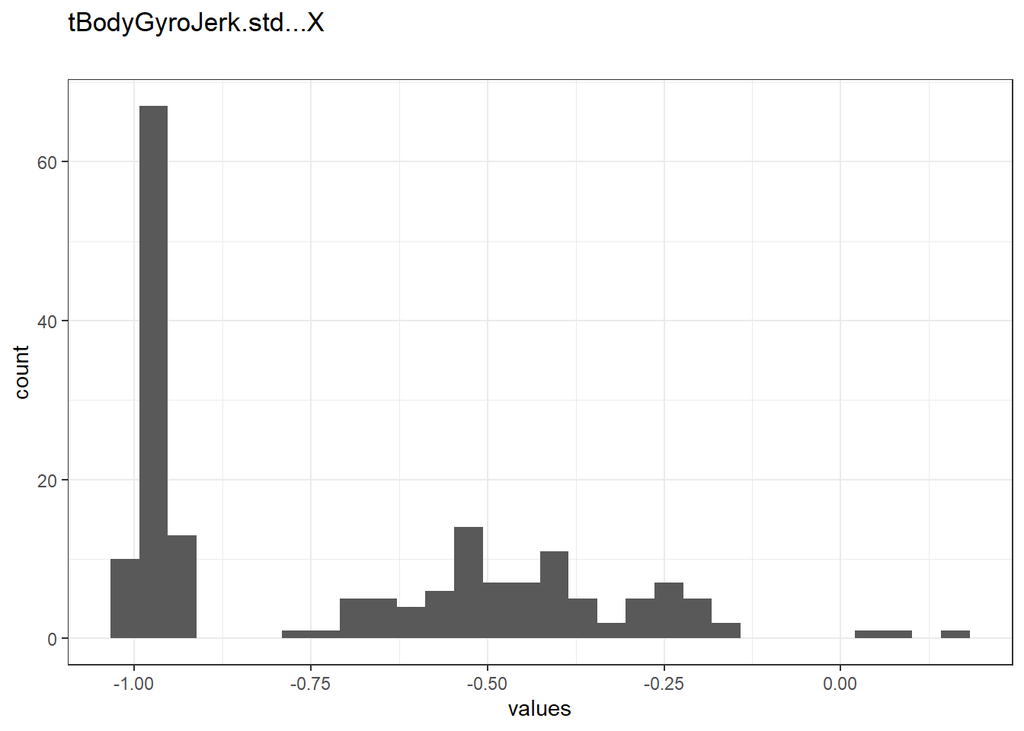

Distribution of values for tBodyGyroJerk.std…X

0 missing values.

#### Summary statistics

| name | data_type | n_missing | complete_rate | min | median | max | mean | sd | hist | label |
| --- | --- | --- | --- | --- | --- | --- | --- | --- | --- | --- |
| tBodyGyroJerk.std…X | numeric | 0 | 1 | -1 | -0.84 | 0.18 | -0.7036327 | 0.3008361 | ▇▂▃▂▁ | NA |

### tBodyGyroJerk.std…Y

#### Distribution

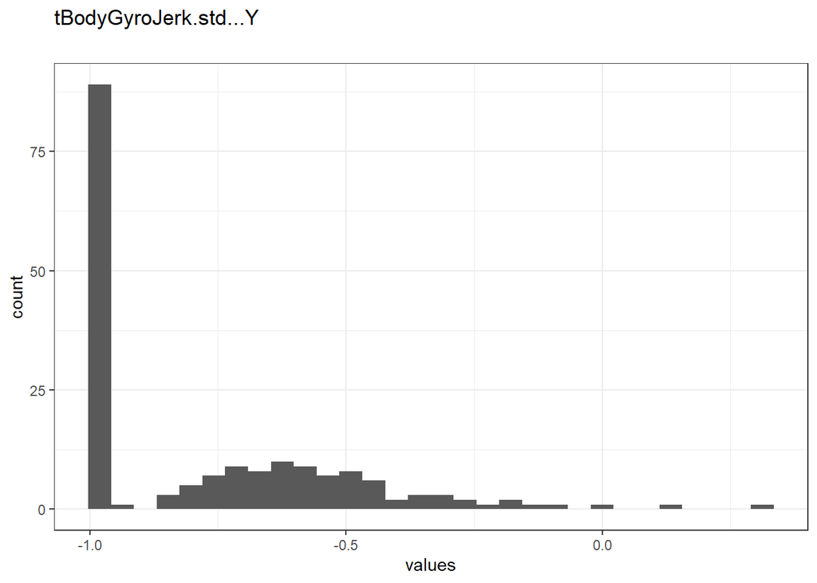

Distribution of values for tBodyGyroJerk.std…Y

0 missing values.

#### Summary statistics

| name | data_type | n_missing | complete_rate | min | median | max | mean | sd | hist | label |
| --- | --- | --- | --- | --- | --- | --- | --- | --- | --- | --- |
| tBodyGyroJerk.std…Y | numeric | 0 | 1 | -1 | -0.89 | 0.3 | -0.7635518 | 0.2672885 | ▇▃▂▁▁ | NA |

### tBodyGyroJerk.std…Z

#### Distribution

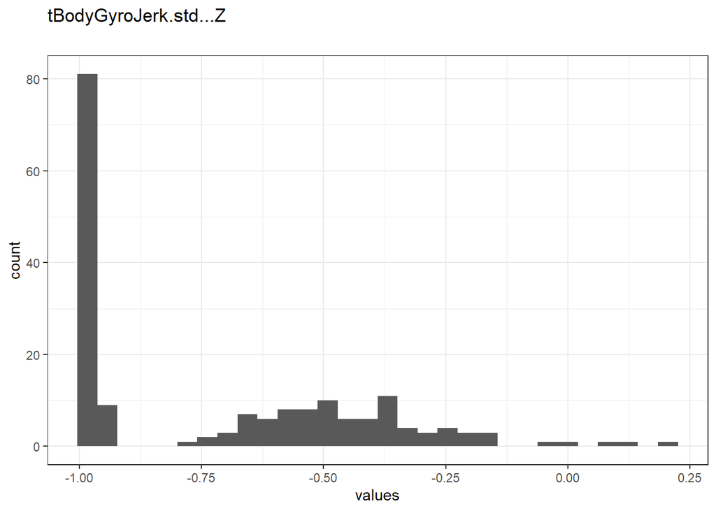

Distribution of values for tBodyGyroJerk.std…Z

0 missing values.

#### Summary statistics

| name | data_type | n_missing | complete_rate | min | median | max | mean | sd | hist | label |
| --- | --- | --- | --- | --- | --- | --- | --- | --- | --- | --- |
| tBodyGyroJerk.std…Z | numeric | 0 | 1 | -1 | -0.86 | 0.19 | -0.7095592 | 0.3045394 | ▇▃▃▁▁ | NA |

### tBodyAccMag.mean..

#### Distribution

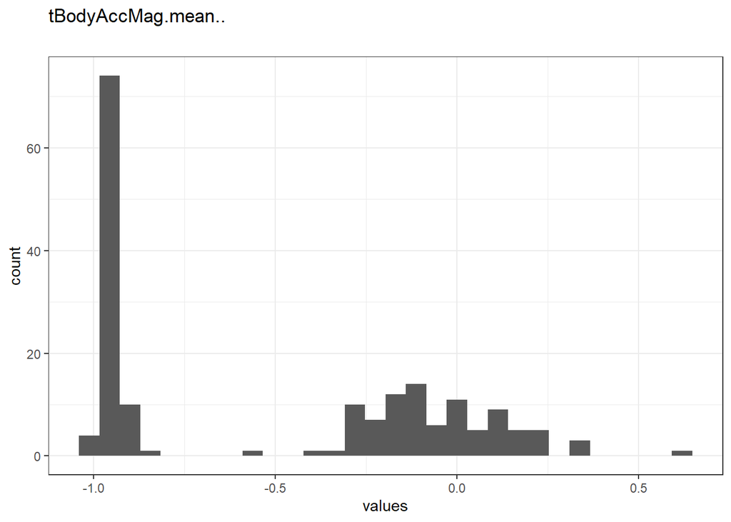

Distribution of values for tBodyAccMag.mean..

0 missing values.

#### Summary statistics

| name | data_type | n_missing | complete_rate | min | median | max | mean | sd | hist | label |
| --- | --- | --- | --- | --- | --- | --- | --- | --- | --- | --- |
| tBodyAccMag.mean.. | numeric | 0 | 1 | -0.99 | -0.48 | 0.64 | -0.4972897 | 0.4728834 | ▇▁▅▃▁ | NA |

### tBodyAccMag.std..

#### Distribution

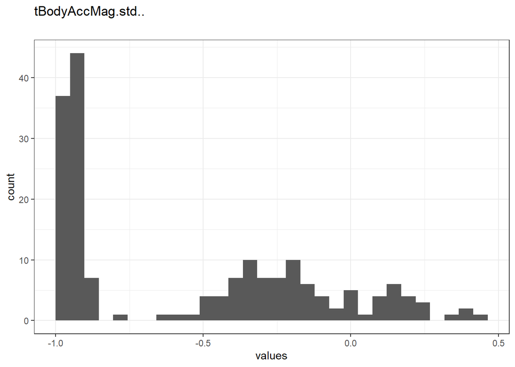

Distribution of values for tBodyAccMag.std..

0 missing values.

#### Summary statistics

| name | data_type | n_missing | complete_rate | min | median | max | mean | sd | hist | label |
| --- | --- | --- | --- | --- | --- | --- | --- | --- | --- | --- |
| tBodyAccMag.std.. | numeric | 0 | 1 | -0.99 | -0.61 | 0.43 | -0.5439087 | 0.4310448 | ▇▁▅▂▁ | NA |

### tGravityAccMag.mean..

#### Distribution

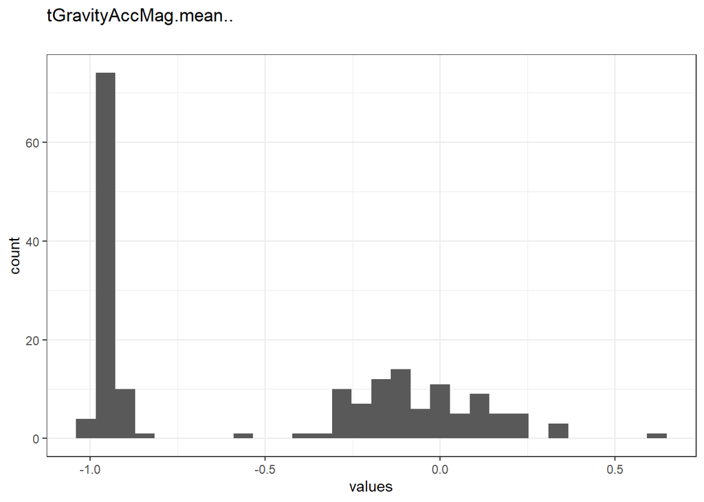

Distribution of values for tGravityAccMag.mean..

0 missing values.

#### Summary statistics

| name | data_type | n_missing | complete_rate | min | median | max | mean | sd | hist | label |
| --- | --- | --- | --- | --- | --- | --- | --- | --- | --- | --- |
| tGravityAccMag.mean.. | numeric | 0 | 1 | -0.99 | -0.48 | 0.64 | -0.4972897 | 0.4728834 | ▇▁▅▃▁ | NA |

### tGravityAccMag.std..

#### Distribution

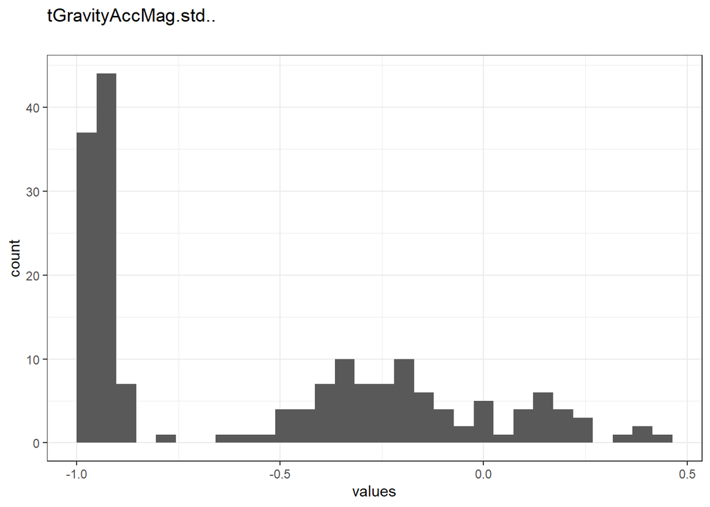

Distribution of values for tGravityAccMag.std..

0 missing values.

#### Summary statistics

| name | data_type | n_missing | complete_rate | min | median | max | mean | sd | hist | label |
| --- | --- | --- | --- | --- | --- | --- | --- | --- | --- | --- |
| tGravityAccMag.std.. | numeric | 0 | 1 | -0.99 | -0.61 | 0.43 | -0.5439087 | 0.4310448 | ▇▁▅▂▁ | NA |

### tBodyAccJerkMag.mean..

#### Distribution

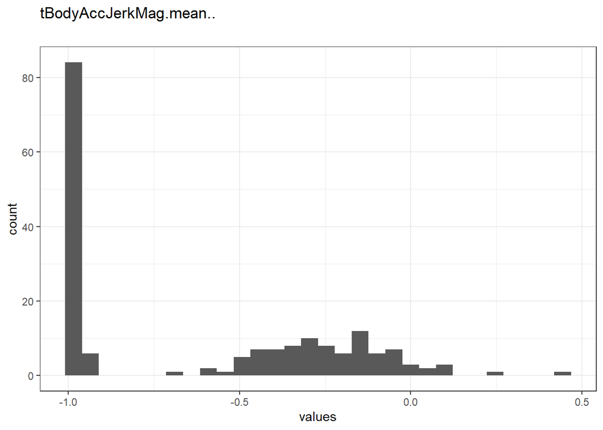

Distribution of values for tBodyAccJerkMag.mean..

0 missing values.

#### Summary statistics

| name | data_type | n_missing | complete_rate | min | median | max | mean | sd | hist | label |
| --- | --- | --- | --- | --- | --- | --- | --- | --- | --- | --- |
| tBodyAccJerkMag.mean.. | numeric | 0 | 1 | -0.99 | -0.82 | 0.43 | -0.6079296 | 0.3965272 | ▇▂▅▂▁ | NA |

### tBodyAccJerkMag.std..

#### Distribution

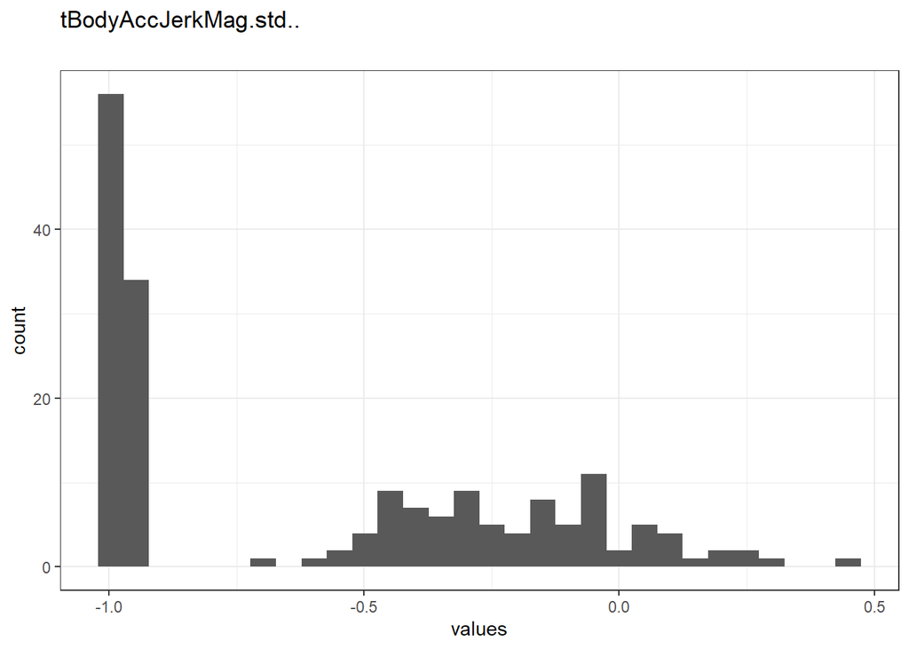

Distribution of values for tBodyAccJerkMag.std..

0 missing values.

#### Summary statistics

| name | data_type | n_missing | complete_rate | min | median | max | mean | sd | hist | label |
| --- | --- | --- | --- | --- | --- | --- | --- | --- | --- | --- |
| tBodyAccJerkMag.std.. | numeric | 0 | 1 | -0.99 | -0.8 | 0.45 | -0.5841756 | 0.4227953 | ▇▂▃▂▁ | NA |

### tBodyGyroMag.mean..

#### Distribution

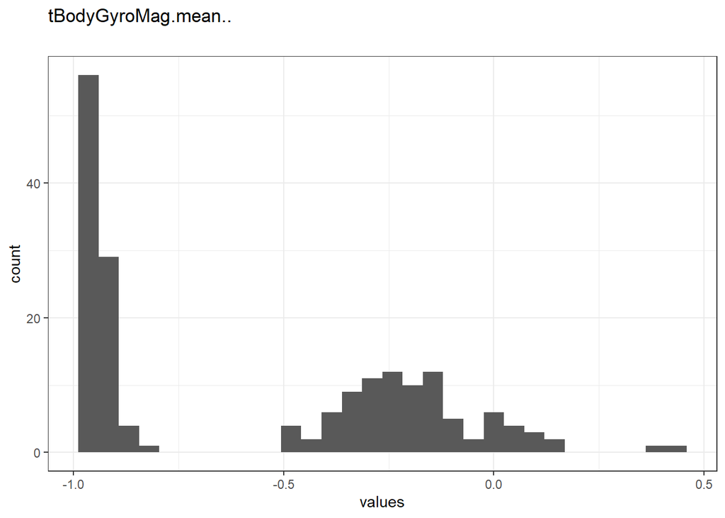

Distribution of values for tBodyGyroMag.mean..

0 missing values.

#### Summary statistics

| name | data_type | n_missing | complete_rate | min | median | max | mean | sd | hist | label |
| --- | --- | --- | --- | --- | --- | --- | --- | --- | --- | --- |
| tBodyGyroMag.mean.. | numeric | 0 | 1 | -0.98 | -0.66 | 0.42 | -0.5651631 | 0.3977338 | ▇▁▅▂▁ | NA |

### tBodyGyroMag.std..

#### Distribution

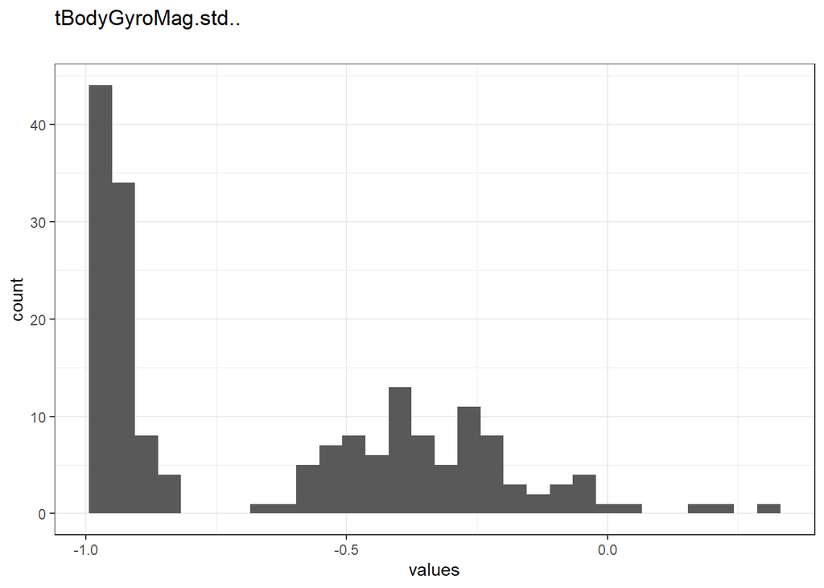

Distribution of values for tBodyGyroMag.std..

0 missing values.

#### Summary statistics

| name | data_type | n_missing | complete_rate | min | median | max | mean | sd | hist | label |
| --- | --- | --- | --- | --- | --- | --- | --- | --- | --- | --- |
| tBodyGyroMag.std.. | numeric | 0 | 1 | -0.98 | -0.74 | 0.3 | -0.6303947 | 0.3368827 | ▇▂▅▂▁ | NA |

### tBodyGyroJerkMag.mean..

#### Distribution

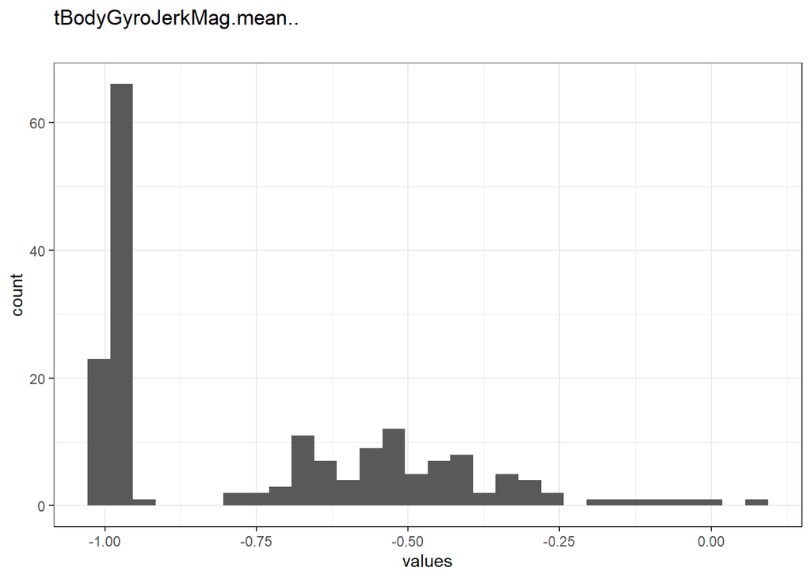

Distribution of values for tBodyGyroJerkMag.mean..

0 missing values.

#### Summary statistics

| name | data_type | n_missing | complete_rate | min | median | max | mean | sd | hist | label |
| --- | --- | --- | --- | --- | --- | --- | --- | --- | --- | --- |
| tBodyGyroJerkMag.mean.. | numeric | 0 | 1 | -1 | -0.86 | 0.088 | -0.7363693 | 0.2767541 | ▇▃▃▁▁ | NA |

### tBodyGyroJerkMag.std..

#### Distribution

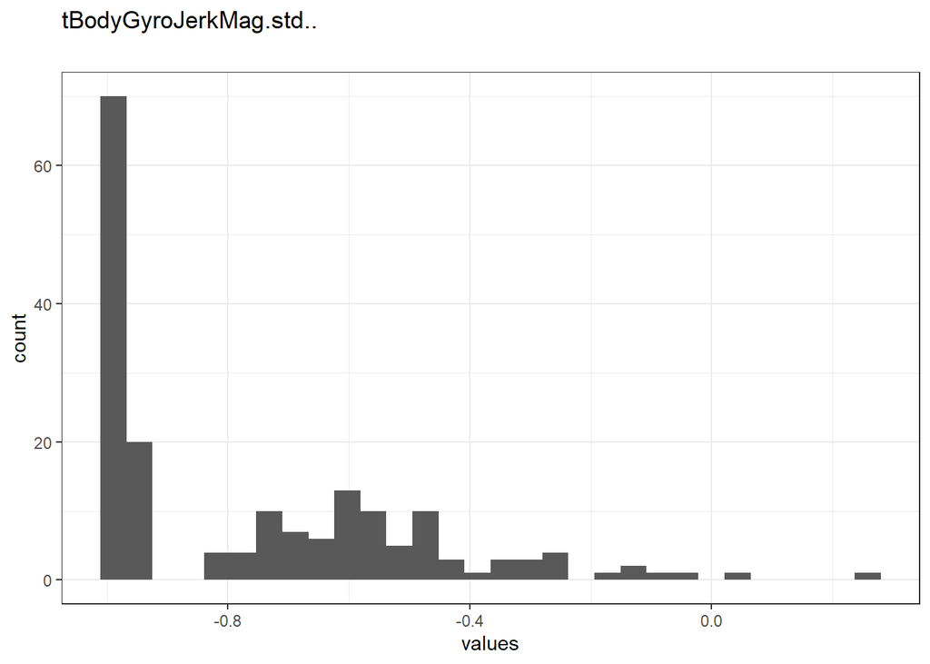

Distribution of values for tBodyGyroJerkMag.std..

0 missing values.

#### Summary statistics

| name | data_type | n_missing | complete_rate | min | median | max | mean | sd | hist | label |
| --- | --- | --- | --- | --- | --- | --- | --- | --- | --- | --- |
| tBodyGyroJerkMag.std.. | numeric | 0 | 1 | -1 | -0.88 | 0.25 | -0.7550152 | 0.2655057 | ▇▃▂▁▁ | NA |

### fBodyAcc.mean…X

#### Distribution

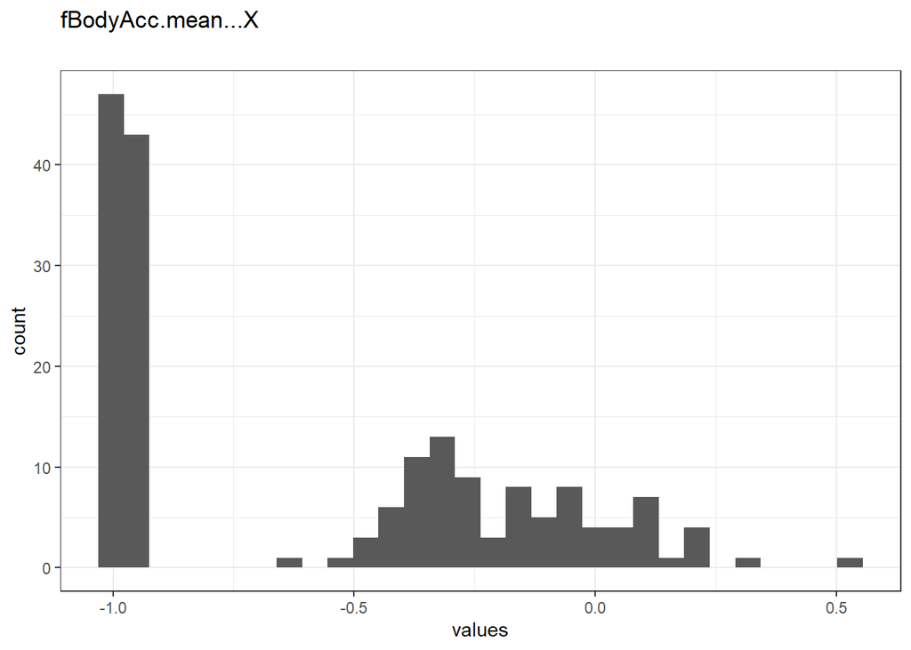

Distribution of values for fBodyAcc.mean…X

0 missing values.

#### Summary statistics

| name | data_type | n_missing | complete_rate | min | median | max | mean | sd | hist | label |
| --- | --- | --- | --- | --- | --- | --- | --- | --- | --- | --- |
| fBodyAcc.mean…X | numeric | 0 | 1 | -1 | -0.77 | 0.54 | -0.5758 | 0.4300214 | ▇▁▃▂▁ | NA |

### fBodyAcc.mean…Y

#### Distribution

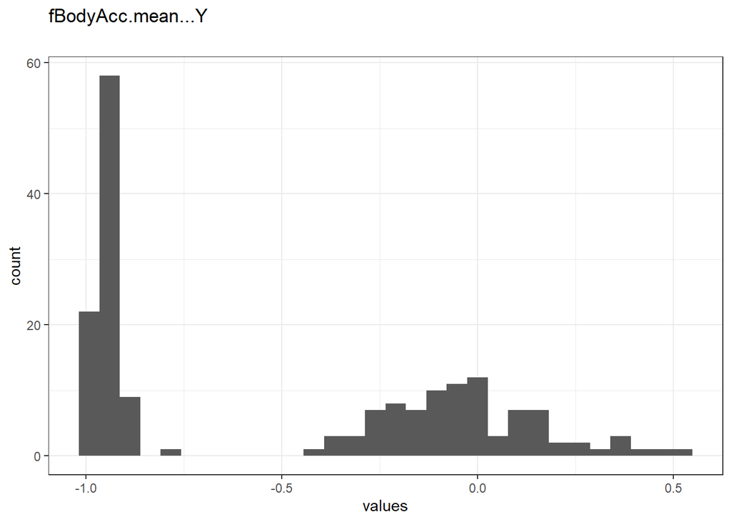

Distribution of values for fBodyAcc.mean…Y

0 missing values.

#### Summary statistics

| name | data_type | n_missing | complete_rate | min | median | max | mean | sd | hist | label |
| --- | --- | --- | --- | --- | --- | --- | --- | --- | --- | --- |
| fBodyAcc.mean…Y | numeric | 0 | 1 | -0.99 | -0.59 | 0.52 | -0.4887327 | 0.4806496 | ▇▁▃▃▁ | NA |

### fBodyAcc.mean…Z

#### Distribution

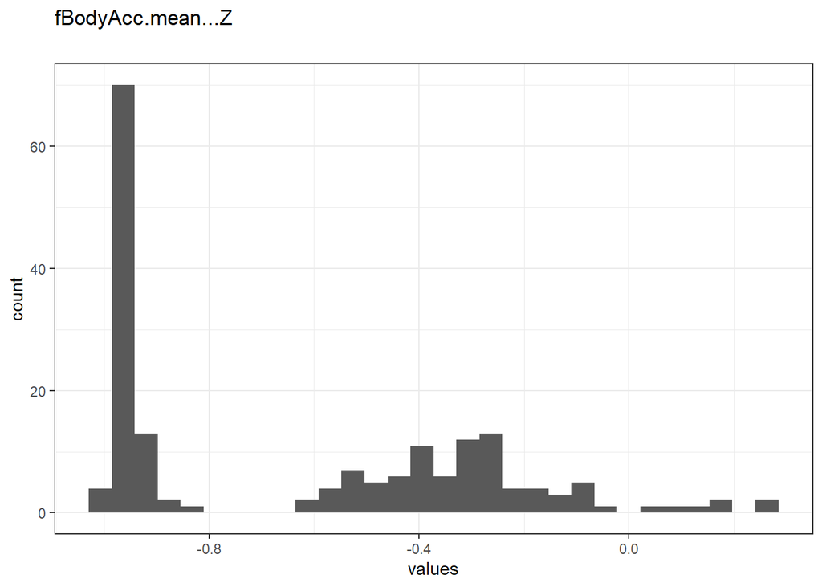

Distribution of values for fBodyAcc.mean…Z

0 missing values.

#### Summary statistics

| name | data_type | n_missing | complete_rate | min | median | max | mean | sd | hist | label |
| --- | --- | --- | --- | --- | --- | --- | --- | --- | --- | --- |
| fBodyAcc.mean…Z | numeric | 0 | 1 | -0.99 | -0.72 | 0.28 | -0.6297388 | 0.3556469 | ▇▂▅▁▁ | NA |

### fBodyAcc.std…X

#### Distribution

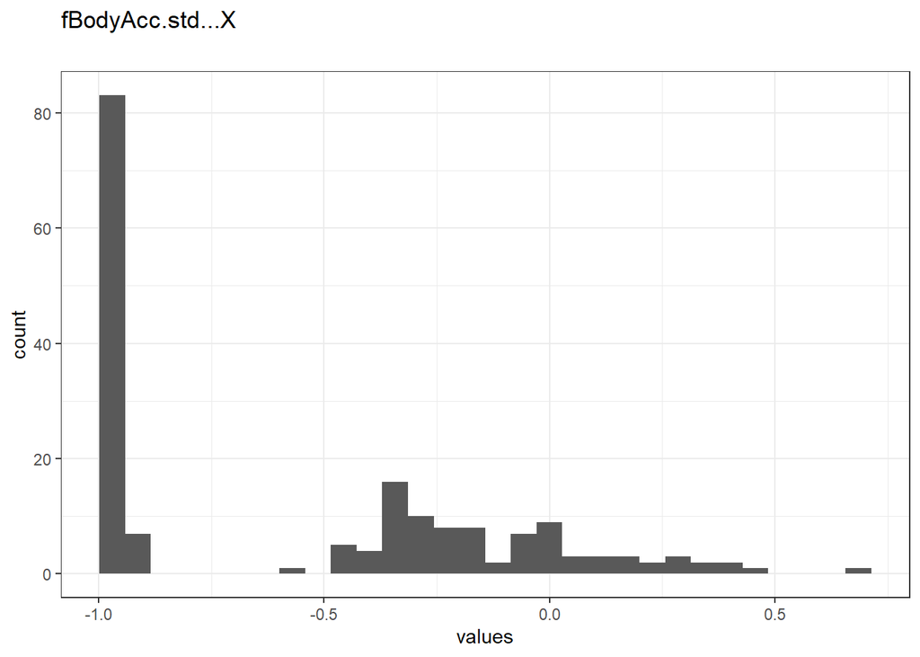

Distribution of values for fBodyAcc.std…X

0 missing values.

#### Summary statistics

| name | data_type | n_missing | complete_rate | min | median | max | mean | sd | hist | label |
| --- | --- | --- | --- | --- | --- | --- | --- | --- | --- | --- |
| fBodyAcc.std…X | numeric | 0 | 1 | -1 | -0.75 | 0.66 | -0.5522011 | 0.4600233 | ▇▂▅▂▁ | NA |

### fBodyAcc.std…Y

#### Distribution

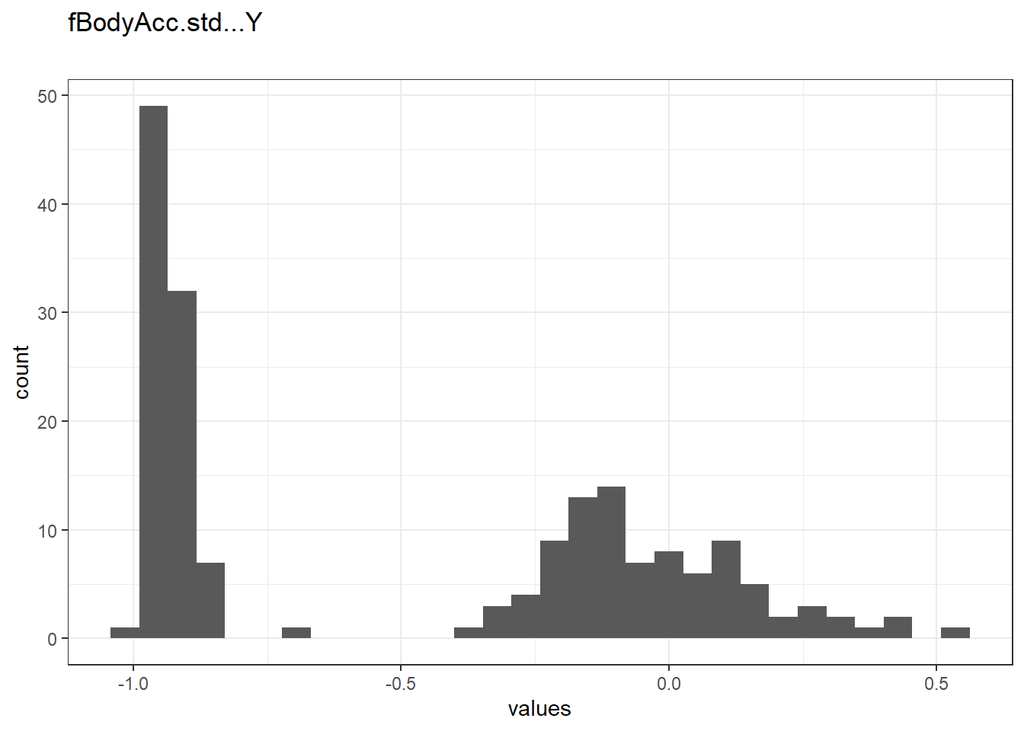

Distribution of values for fBodyAcc.std…Y

0 missing values.

#### Summary statistics

| name | data_type | n_missing | complete_rate | min | median | max | mean | sd | hist | label |
| --- | --- | --- | --- | --- | --- | --- | --- | --- | --- | --- |
| fBodyAcc.std…Y | numeric | 0 | 1 | -0.99 | -0.51 | 0.56 | -0.4814787 | 0.4740277 | ▇▁▅▃▁ | NA |

### fBodyAcc.std…Z

#### Distribution

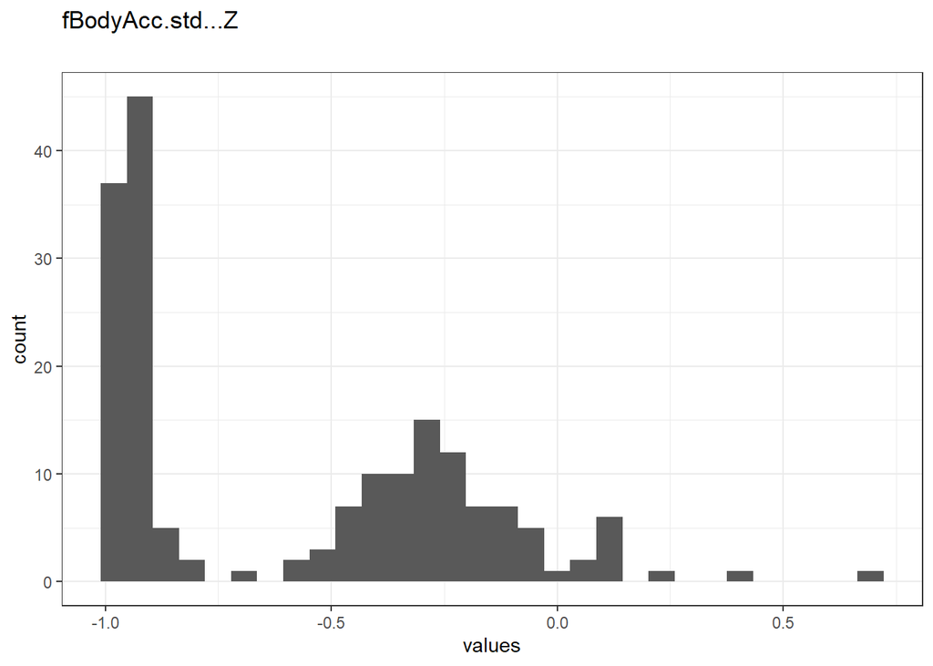

Distribution of values for fBodyAcc.std…Z

0 missing values.

#### Summary statistics

| name | data_type | n_missing | complete_rate | min | median | max | mean | sd | hist | label |
| --- | --- | --- | --- | --- | --- | --- | --- | --- | --- | --- |
| fBodyAcc.std…Z | numeric | 0 | 1 | -0.99 | -0.64 | 0.69 | -0.5823614 | 0.3880902 | ▇▃▅▁▁ | NA |

### fBodyAccJerk.mean…X

#### Distribution

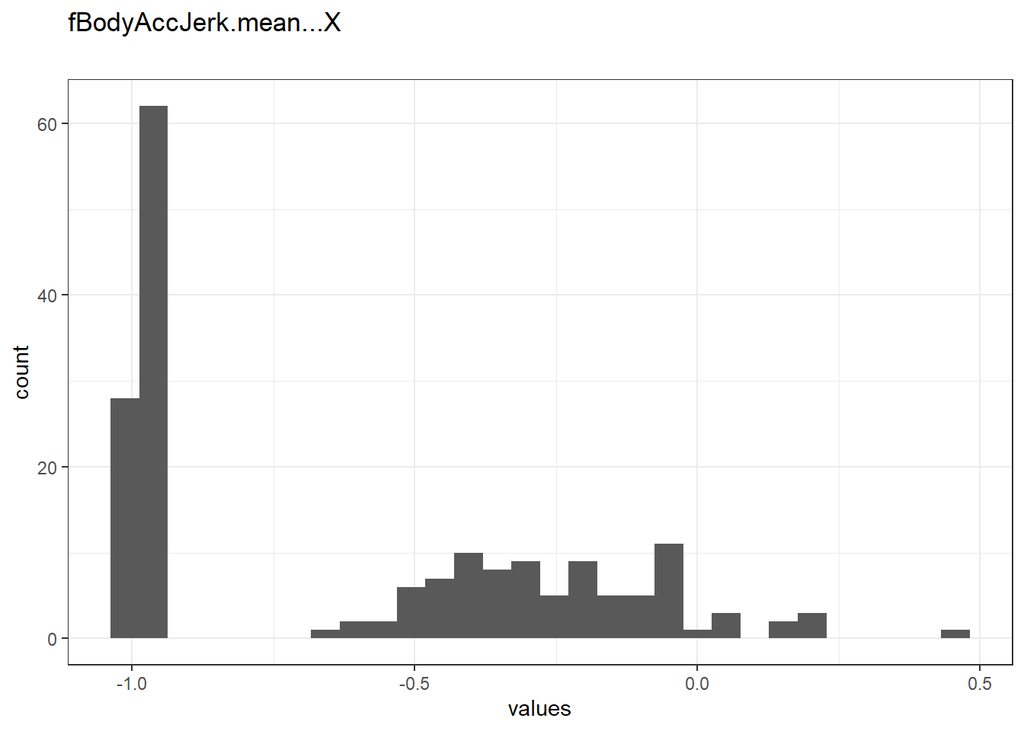

Distribution of values for fBodyAccJerk.mean…X

0 missing values.

#### Summary statistics

| name | data_type | n_missing | complete_rate | min | median | max | mean | sd | hist | label |
| --- | --- | --- | --- | --- | --- | --- | --- | --- | --- | --- |
| fBodyAccJerk.mean…X | numeric | 0 | 1 | -0.99 | -0.81 | 0.47 | -0.6139282 | 0.3982896 | ▇▂▃▂▁ | NA |

### fBodyAccJerk.mean…Y

#### Distribution

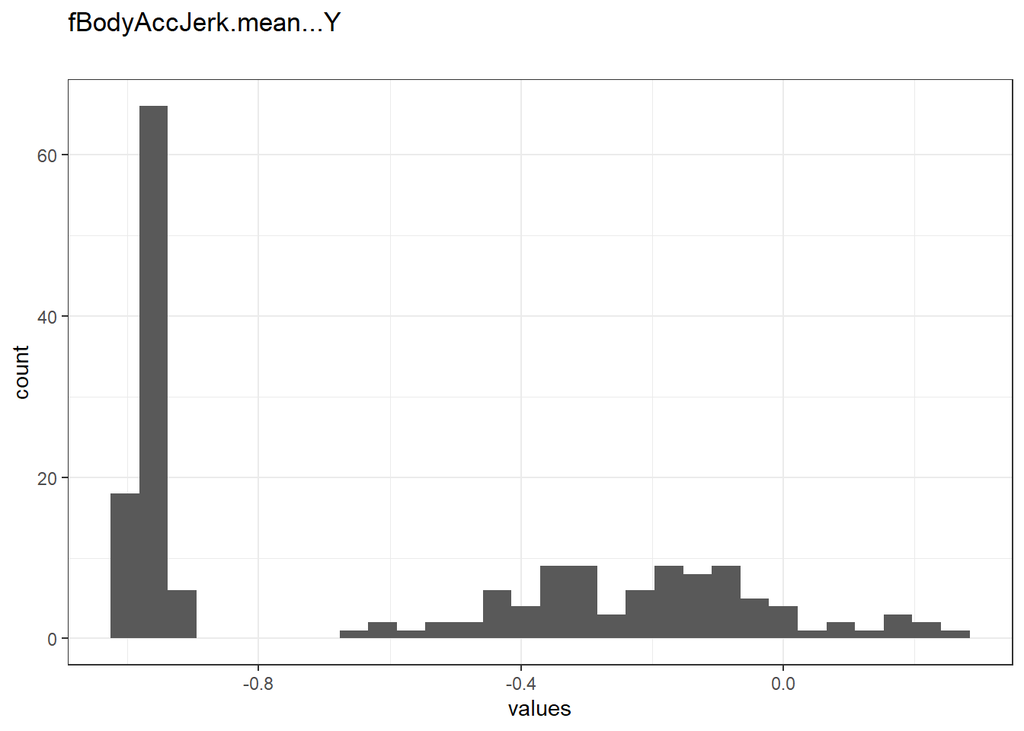

Distribution of values for fBodyAccJerk.mean…Y

0 missing values.

#### Summary statistics

| name | data_type | n_missing | complete_rate | min | median | max | mean | sd | hist | label |
| --- | --- | --- | --- | --- | --- | --- | --- | --- | --- | --- |
| fBodyAccJerk.mean…Y | numeric | 0 | 1 | -0.99 | -0.78 | 0.28 | -0.5881631 | 0.4077491 | ▇▁▃▃▁ | NA |

### fBodyAccJerk.mean…Z

#### Distribution

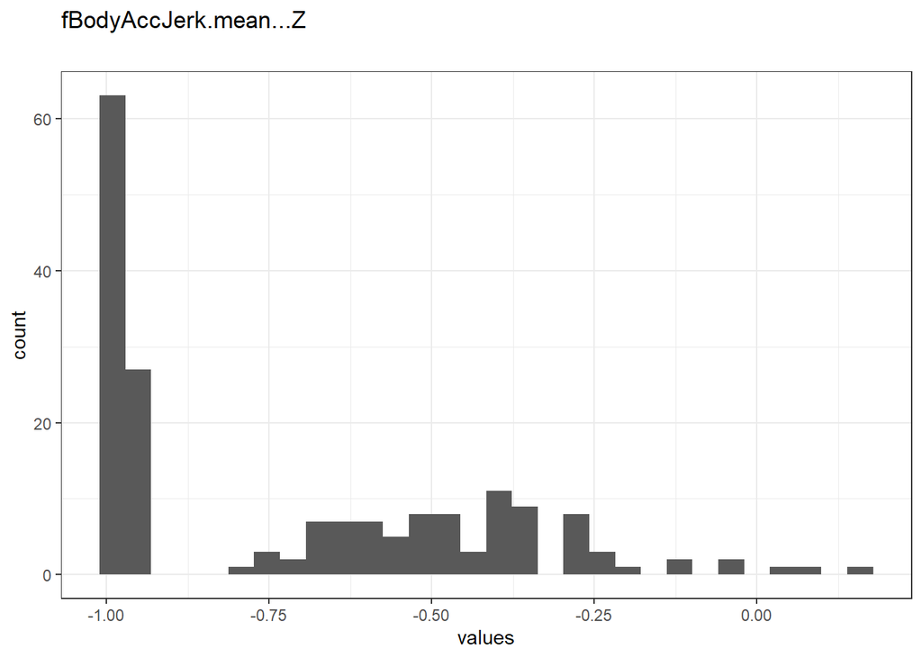

Distribution of values for fBodyAccJerk.mean…Z

0 missing values.

#### Summary statistics

| name | data_type | n_missing | complete_rate | min | median | max | mean | sd | hist | label |
| --- | --- | --- | --- | --- | --- | --- | --- | --- | --- | --- |
| fBodyAccJerk.mean…Z | numeric | 0 | 1 | -0.99 | -0.87 | 0.16 | -0.7143585 | 0.2970225 | ▇▂▃▁▁ | NA |

### fBodyAccJerk.std…X

#### Distribution

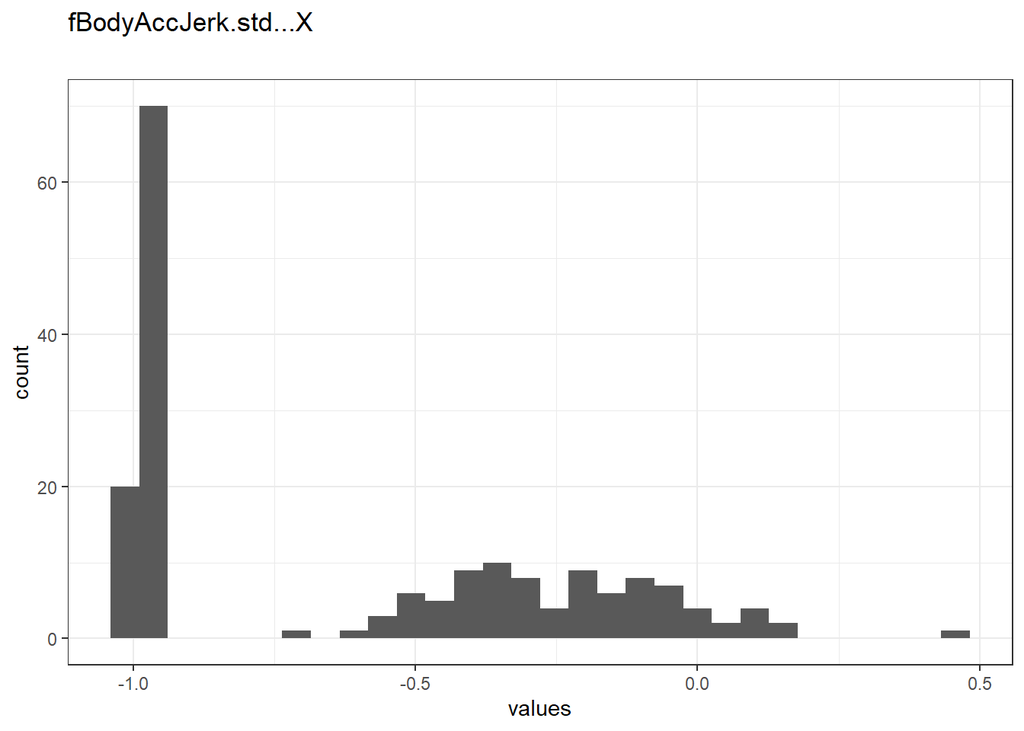

Distribution of values for fBodyAccJerk.std…X

0 missing values.

#### Summary statistics

| name | data_type | n_missing | complete_rate | min | median | max | mean | sd | hist | label |
| --- | --- | --- | --- | --- | --- | --- | --- | --- | --- | --- |
| fBodyAccJerk.std…X | numeric | 0 | 1 | -1 | -0.83 | 0.48 | -0.6121033 | 0.4004506 | ▇▂▃▂▁ | NA |

### fBodyAccJerk.std…Y

#### Distribution

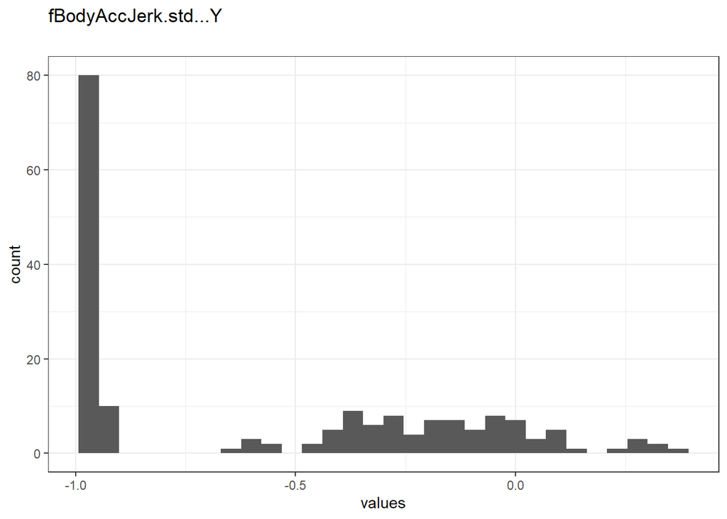

Distribution of values for fBodyAccJerk.std…Y

0 missing values.

#### Summary statistics

| name | data_type | n_missing | complete_rate | min | median | max | mean | sd | hist | label |
| --- | --- | --- | --- | --- | --- | --- | --- | --- | --- | --- |
| fBodyAccJerk.std…Y | numeric | 0 | 1 | -0.99 | -0.79 | 0.35 | -0.570731 | 0.4319873 | ▇▁▃▃▁ | NA |

### fBodyAccJerk.std…Z

#### Distribution

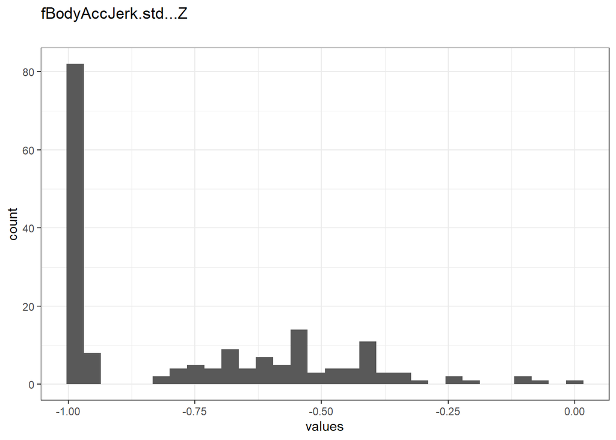

Distribution of values for fBodyAccJerk.std…Z

0 missing values.

#### Summary statistics

| name | data_type | n_missing | complete_rate | min | median | max | mean | sd | hist | label |
| --- | --- | --- | --- | --- | --- | --- | --- | --- | --- | --- |
| fBodyAccJerk.std…Z | numeric | 0 | 1 | -0.99 | -0.9 | -0.0062 | -0.7564894 | 0.2570577 | ▇▃▃▁▁ | NA |

### fBodyGyro.mean…X

#### Distribution

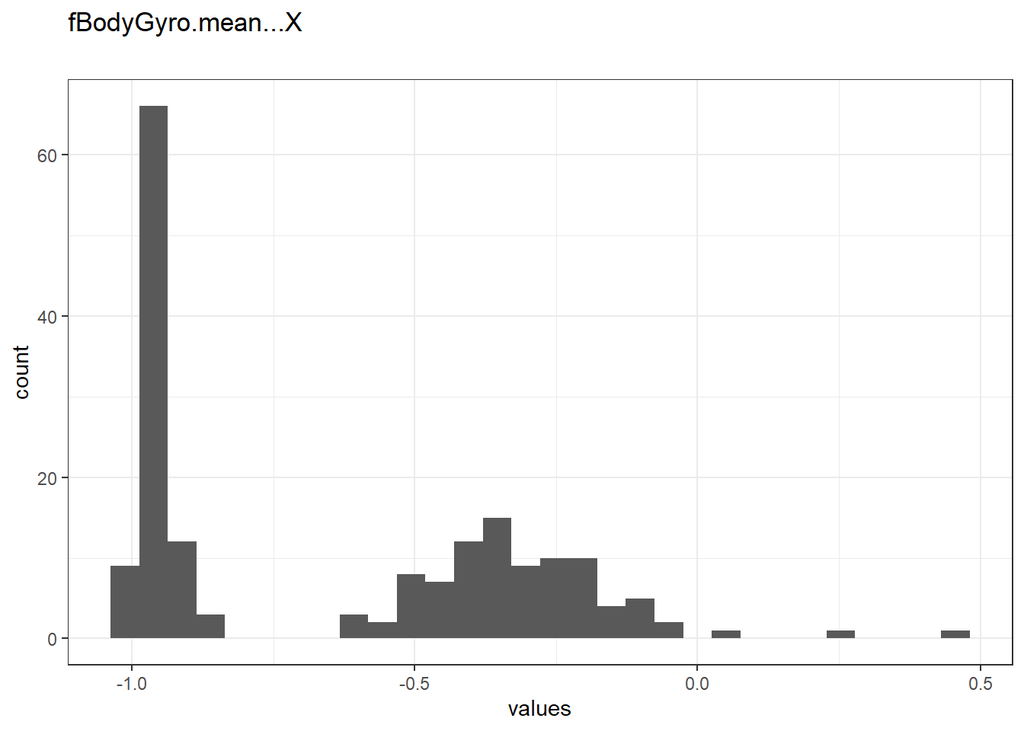

Distribution of values for fBodyGyro.mean…X

0 missing values.

#### Summary statistics

| name | data_type | n_missing | complete_rate | min | median | max | mean | sd | hist | label |
| --- | --- | --- | --- | --- | --- | --- | --- | --- | --- | --- |
| fBodyGyro.mean…X | numeric | 0 | 1 | -0.99 | -0.73 | 0.47 | -0.6367396 | 0.3467628 | ▇▂▅▁▁ | NA |

### fBodyGyro.mean…Y

#### Distribution

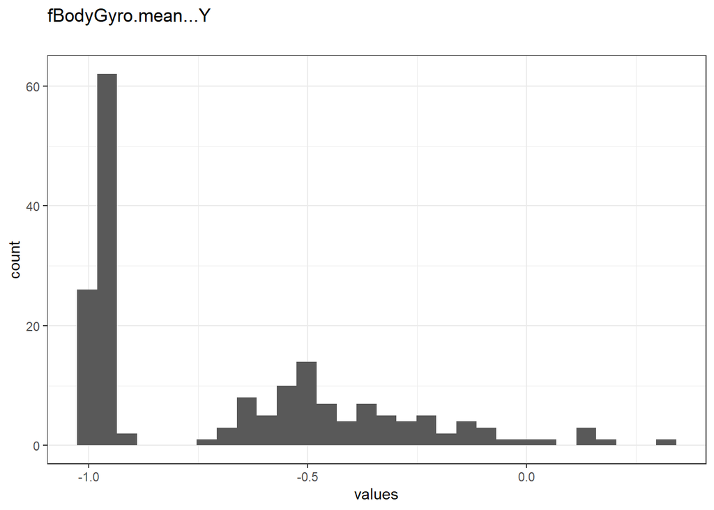

Distribution of values for fBodyGyro.mean…Y

0 missing values.

#### Summary statistics

| name | data_type | n_missing | complete_rate | min | median | max | mean | sd | hist | label |
| --- | --- | --- | --- | --- | --- | --- | --- | --- | --- | --- |
| fBodyGyro.mean…Y | numeric | 0 | 1 | -0.99 | -0.81 | 0.33 | -0.6766868 | 0.3319182 | ▇▃▃▁▁ | NA |

### fBodyGyro.mean…Z

#### Distribution

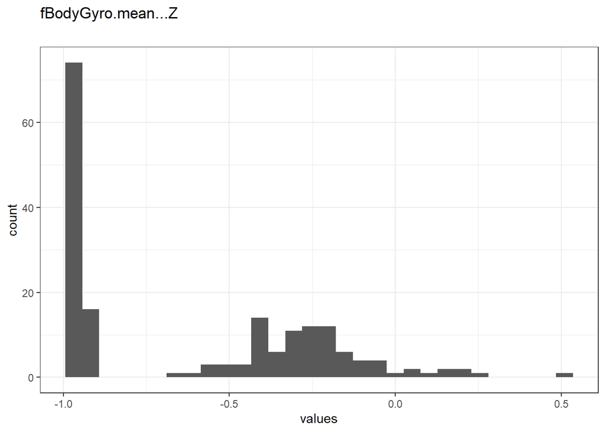

Distribution of values for fBodyGyro.mean…Z

0 missing values.

#### Summary statistics

| name | data_type | n_missing | complete_rate | min | median | max | mean | sd | hist | label |
| --- | --- | --- | --- | --- | --- | --- | --- | --- | --- | --- |
| fBodyGyro.mean…Z | numeric | 0 | 1 | -0.99 | -0.79 | 0.49 | -0.6043912 | 0.3842603 | ▇▂▅▁▁ | NA |

### fBodyGyro.std…X

#### Distribution

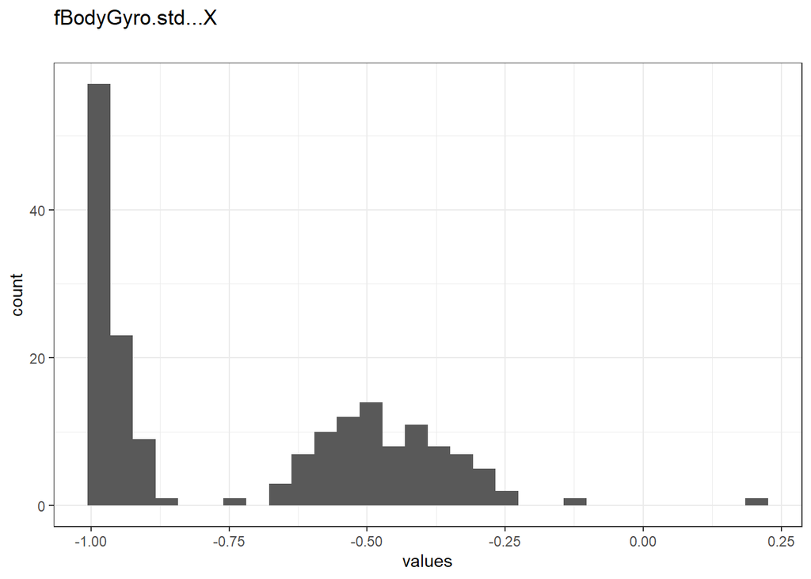

Distribution of values for fBodyGyro.std…X

0 missing values.

#### Summary statistics

| name | data_type | n_missing | complete_rate | min | median | max | mean | sd | hist | label |
| --- | --- | --- | --- | --- | --- | --- | --- | --- | --- | --- |
| fBodyGyro.std…X | numeric | 0 | 1 | -0.99 | -0.81 | 0.2 | -0.7110357 | 0.272789 | ▇▂▅▁▁ | NA |

### fBodyGyro.std…Y

#### Distribution

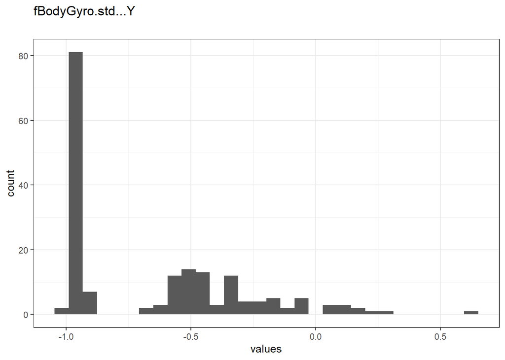

Distribution of values for fBodyGyro.std…Y

0 missing values.

#### Summary statistics

| name | data_type | n_missing | complete_rate | min | median | max | mean | sd | hist | label |
| --- | --- | --- | --- | --- | --- | --- | --- | --- | --- | --- |
| fBodyGyro.std…Y | numeric | 0 | 1 | -0.99 | -0.8 | 0.65 | -0.6454334 | 0.3634445 | ▇▅▂▁▁ | NA |

### fBodyGyro.std…Z

#### Distribution

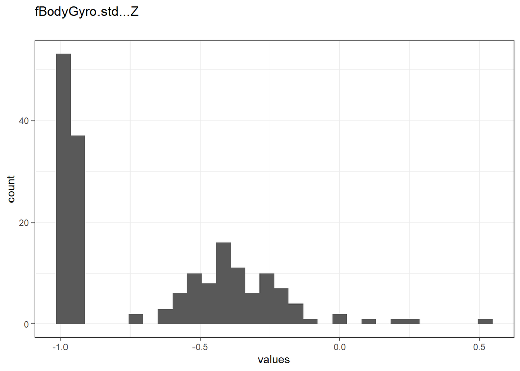

Distribution of values for fBodyGyro.std…Z

0 missing values.

#### Summary statistics

| name | data_type | n_missing | complete_rate | min | median | max | mean | sd | hist | label |
| --- | --- | --- | --- | --- | --- | --- | --- | --- | --- | --- |
| fBodyGyro.std…Z | numeric | 0 | 1 | -0.99 | -0.82 | 0.52 | -0.6577466 | 0.3362014 | ▇▃▃▁▁ | NA |

### fBodyAccMag.mean..

#### Distribution

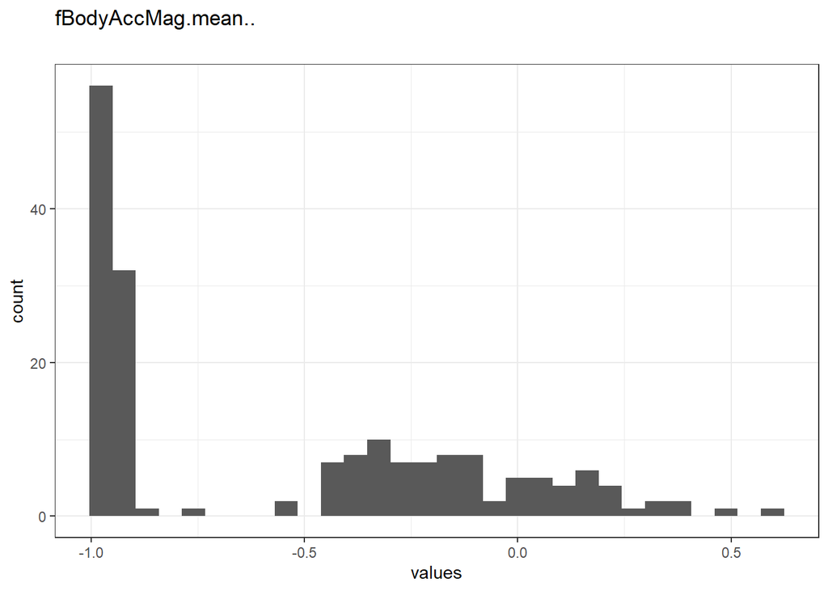

Distribution of values for fBodyAccMag.mean..

0 missing values.

#### Summary statistics

| name | data_type | n_missing | complete_rate | min | median | max | mean | sd | hist | label |
| --- | --- | --- | --- | --- | --- | --- | --- | --- | --- | --- |
| fBodyAccMag.mean.. | numeric | 0 | 1 | -0.99 | -0.67 | 0.59 | -0.5365167 | 0.4516451 | ▇▂▃▂▁ | NA |

### fBodyAccMag.std..

#### Distribution

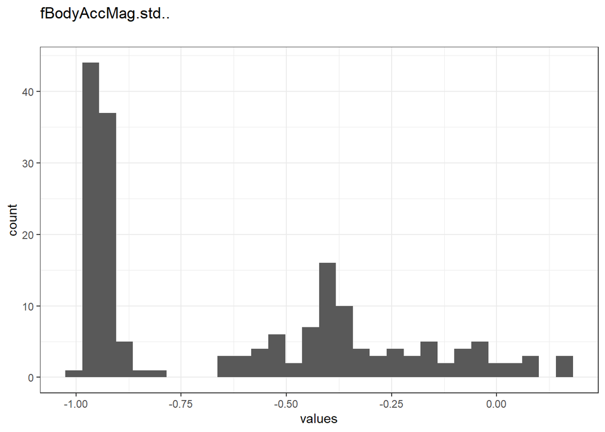

Distribution of values for fBodyAccMag.std..

0 missing values.

#### Summary statistics

| name | data_type | n_missing | complete_rate | min | median | max | mean | sd | hist | label |
| --- | --- | --- | --- | --- | --- | --- | --- | --- | --- | --- |
| fBodyAccMag.std.. | numeric | 0 | 1 | -0.99 | -0.65 | 0.18 | -0.6209633 | 0.3529148 | ▇▁▃▂▁ | NA |